# Additional Analyses

## Library

```r
library(dplyr)
```

```r
library(ggplot2)
library(MatchIt)
library(cobalt)
library(psych)
library(effsize)
library(forestplot)
## set options for bal.tab function in cobalt package
set.cobalt.options(binary = "std") # for binary covariates used in the matching procedure the bal.tab function will now display standardized mean differences instead of the raw difference
```

## Load data

```r
data_main = read.csv(file = "data/data_main.csv")[,-1]
```

## 1. PSM for partner preferences

Check for missings in covariates to be matched - psm cannot handle missings - covariates: language, age, country, relationship status, relationship length - additionally match for: interest_nonsexrel, interest_monrel, interest_single

```r
# MatchIt does not allow missing values
data_main_nomiss_add <- data_main %>% select(id, language, age, sex, country, relationship_status, relationship_length, sexual_orientation,
                                         pref_imp_ks, pref_imp_att, pref_imp_fs, pref_imp_ca,
                                         pref_imp_ei, pref_imp_sexually_experienced,
                                         interest_nonsexrel, interest_monrel, interest_single) %>%
                                  na.omit()

table(is.na(data_main_nomiss_add)) # no more NAs in data set
```

```
##
##  FALSE
## 641563
```

Check if correct variable type

```r
typeof(data_main_nomiss_add$sexual_orientation) # is variable of type character, but for PSM it needs to be a factor
```

```
## [1] "character"
```

```r
data_main_nomiss_add$sexual_orientation = as.factor(data_main_nomiss_add$sexual_orientation) # convert to factor
levels(data_main_nomiss_add$sexual_orientation) # check levels of factor
```

```
## [1] "Asexual"               "Straight/Heterosexual"
```

```r
data_main_nomiss_add$sexual_orientation = factor(data_main_nomiss_add$sexual_orientation,
                                             levels=rev(levels(data_main_nomiss_add$sexual_orientation))) # reverse order of factor levels
levels(data_main_nomiss_add$sexual_orientation) # check factor level order
```

```
## [1] "Straight/Heterosexual" "Asexual"
```

### Matching with NNM

```r
nnm_add <- matchit(sexual_orientation ~ language + age + country + relationship_status +
                     relationship_length + interest_nonsexrel + interest_monrel +
                     interest_single,
                   method = "nearest", data = data_main_nomiss_add)

nnm_add_data <- match.data(nnm_add)

nrow(nnm_add_data) # 636 observations
```

```
## [1] 636
```

```r
table(nnm_add_data$subclass) # data includes only pairs of two observations
```

```
##
##   1   2   3   4   5   6   7   8   9  10  11  12  13  14  15  16  17  18  19  20
##   2   2   2   2   2   2   2   2   2   2   2   2   2   2   2   2   2   2   2   2
##  21  22  23  24  25  26  27  28  29  30  31  32  33  34  35  36  37  38  39  40
##   2   2   2   2   2   2   2   2   2   2   2   2   2   2   2   2   2   2   2   2
##  41  42  43  44  45  46  47  48  49  50  51  52  53  54  55  56  57  58  59  60
##   2   2   2   2   2   2   2   2   2   2   2   2   2   2   2   2   2   2   2   2
##  61  62  63  64  65  66  67  68  69  70  71  72  73  74  75  76  77  78  79  80
##   2   2   2   2   2   2   2   2   2   2   2   2   2   2   2   2   2   2   2   2
##  81  82  83  84  85  86  87  88  89  90  91  92  93  94  95  96  97  98  99 100
##   2   2   2   2   2   2   2   2   2   2   2   2   2   2   2   2   2   2   2   2
## 101 102 103 104 105 106 107 108 109 110 111 112 113 114 115 116 117 118 119 120
##   2   2   2   2   2   2   2   2   2   2   2   2   2   2   2   2   2   2   2   2
## 121 122 123 124 125 126 127 128 129 130 131 132 133 134 135 136 137 138 139 140
##   2   2   2   2   2   2   2   2   2   2   2   2   2   2   2   2   2   2   2   2
```

[output cut: 18 more lines]

```r
dim(nnm_add_data) # 636 observations and 20 variables
```

```
## [1] 636  20
```

### Check balance

```r
summary_nnm_add = summary(nnm_add, standardize = T)
print(summary_nnm_add)
```

```
##
## Call:
## matchit(formula = sexual_orientation ~ language + age + country +
##     relationship_status + relationship_length + interest_nonsexrel +
##     interest_monrel + interest_single, data = data_main_nomiss_add,
##     method = "nearest")
##
## Summary of Balance for All Data:
##                                         Means Treated Means Control
## distance                                       0.1004        0.0076
## languagechinese                                0.0000        0.0064
## languagedanish                                 0.0189        0.0304
## languageenglish                                0.5094        0.2298
## languagefrench                                 0.0629        0.1923
## languagegerman                                 0.1541        0.1470
## languageitalian                                0.0440        0.0658
## languagejapanese                               0.0283        0.0251
## languageportuguese                             0.0535        0.0724
## languagerussian                                0.0157        0.0165
## languagespanish                                0.1132        0.2142
## age                                           24.0660       25.2249
## countryAfghanistan                             0.0000        0.0001
## countryAlbania                                 0.0000        0.0001
## countryAlgeria                                 0.0031        0.0003
## countryAndorra                                 0.0000        0.0002
## countryAngola                                  0.0000        0.0001
## countryAntigua and Barbuda                     0.0000        0.0001
## countryArgentina                               0.0220        0.0152
## countryArmenia                                 0.0000        0.0001
## countryAruba                                   0.0000        0.0001
## countryAustralia                               0.0346        0.0108
## countryAustria                                 0.0094        0.0127
## countryAzerbaijan                              0.0000        0.0000
## countryBahamas, The                            0.0000        0.0001
## countryBahrain                                 0.0000        0.0001
## countryBarbados                                0.0000        0.0001
## countryBelarus                                 0.0000        0.0010
## countryBelgium                                 0.0000        0.0091
## countryBelize                                  0.0000        0.0001
## countryBenin                                   0.0000        0.0000
```

[output cut: 1429 more lines]

```
## countryZimbabwe                            100.0
## relationship_statusLong-term                93.2
## relationship_statusNo relationship          95.2
## relationship_statusShort-term               96.5
## relationship_length                         94.1
## interest_nonsexrel                          92.8
## interest_monrel                             51.9
## interest_single                             91.4
##
## Sample Sizes:
##           Control Treated
## All         37421     318
## Matched       318     318
## Unmatched   37103       0
## Discarded       0       0
```

```r
bal.tab(nnm_add, m.threshold = 0.1, un = T, binary = "std") #smd
```

```
## Call
##  matchit(formula = sexual_orientation ~ language + age + country +
##     relationship_status + relationship_length + interest_nonsexrel +
##     interest_monrel + interest_single, data = data_main_nomiss_add,
##     method = "nearest")
##
## Balance Measures
##                                              Type Diff.Un Diff.Adj
## distance                                 Distance  0.8003   0.0124
## language_chinese                           Binary -0.0803   0.0000
## language_danish                            Binary -0.0844   0.0000
## language_english                           Binary  0.5593   0.0063
## language_french                            Binary -0.5330  -0.0130
## language_german                            Binary  0.0197   0.0348
## language_italian                           Binary -0.1062  -0.0460
## language_japanese                          Binary  0.0190   0.0190
## language_portuguese                        Binary -0.0844  -0.0419
## language_russian                           Binary -0.0066  -0.0758
## language_spanish                           Binary -0.3189   0.0397
## age                                       Contin. -0.1812   0.0718
## country_Afghanistan                        Binary -0.0073   0.0000
## country_Albania                            Binary -0.0090   0.0000
## country_Algeria                            Binary  0.0504   0.0562
## country_Andorra                            Binary -0.0147   0.0000
## country_Angola                             Binary -0.0073   0.0000
## country_Antigua and Barbuda                Binary -0.0104   0.0000
## country_Argentina                          Binary  0.0462   0.0214
## country_Armenia                            Binary -0.0104   0.0000
## country_Aruba                              Binary -0.0073   0.0000
## country_Australia                          Binary  0.1301  -0.0344
## country_Austria                            Binary -0.0337   0.0325
## country_Azerbaijan                         Binary -0.0052   0.0000
## country_Bahamas, The                       Binary -0.0104   0.0000
## country_Bahrain                            Binary -0.0090   0.0000
## country_Barbados                           Binary -0.0104   0.0000
## country_Belarus                            Binary -0.0312   0.0000
## country_Belgium                            Binary -0.0960   0.0000
## country_Belize                             Binary -0.0090   0.0000
## country_Benin                              Binary -0.0052   0.0000
## country_Bhutan                             Binary -0.0052   0.0000
```

[output cut: 333 more lines]

```
##
## Balance tally for mean differences
##                    count
## Balanced, <0.1       182
## Not Balanced, >0.1     0
##
## Variable with the greatest mean difference
##          Variable Diff.Adj    M.Threshold
##  language_russian  -0.0758 Balanced, <0.1
##
## Sample sizes
##           Control Treated
## All         37421     318
## Matched       318     318
## Unmatched   37103       0
```

```r
bal.tab(nnm_add, v.threshold = 2, un = T) #vr (can only be calculated for continuous variables)
```

```
## Call
##  matchit(formula = sexual_orientation ~ language + age + country +
##     relationship_status + relationship_length + interest_nonsexrel +
##     interest_monrel + interest_single, data = data_main_nomiss_add,
##     method = "nearest")
##
## Balance Measures
##                                              Type Diff.Un V.Ratio.Un Diff.Adj
## distance                                 Distance  0.8003    24.0869   0.0124
## language_chinese                           Binary -0.0803          .   0.0000
## language_danish                            Binary -0.0844          .   0.0000
## language_english                           Binary  0.5593          .   0.0063
## language_french                            Binary -0.5330          .  -0.0130
## language_german                            Binary  0.0197          .   0.0348
## language_italian                           Binary -0.1062          .  -0.0460
## language_japanese                          Binary  0.0190          .   0.0190
## language_portuguese                        Binary -0.0844          .  -0.0419
## language_russian                           Binary -0.0066          .  -0.0758
## language_spanish                           Binary -0.3189          .   0.0397
## age                                       Contin. -0.1812     0.7837   0.0718
## country_Afghanistan                        Binary -0.0073          .   0.0000
## country_Albania                            Binary -0.0090          .   0.0000
## country_Algeria                            Binary  0.0504          .   0.0562
## country_Andorra                            Binary -0.0147          .   0.0000
## country_Angola                             Binary -0.0073          .   0.0000
## country_Antigua and Barbuda                Binary -0.0104          .   0.0000
## country_Argentina                          Binary  0.0462          .   0.0214
## country_Armenia                            Binary -0.0104          .   0.0000
## country_Aruba                              Binary -0.0073          .   0.0000
## country_Australia                          Binary  0.1301          .  -0.0344
## country_Austria                            Binary -0.0337          .   0.0325
## country_Azerbaijan                         Binary -0.0052          .   0.0000
## country_Bahamas, The                       Binary -0.0104          .   0.0000
## country_Bahrain                            Binary -0.0090          .   0.0000
## country_Barbados                           Binary -0.0104          .   0.0000
## country_Belarus                            Binary -0.0312          .   0.0000
## country_Belgium                            Binary -0.0960          .   0.0000
## country_Belize                             Binary -0.0090          .   0.0000
## country_Benin                              Binary -0.0052          .   0.0000
## country_Bhutan                             Binary -0.0052          .   0.0000
```

[output cut: 333 more lines]

```
##
## Balance tally for variance ratios
##                  count
## Balanced, <2         6
## Not Balanced, >2     0
##
## Variable with the greatest variance ratio
##         Variable V.Ratio.Adj  V.Threshold
##  interest_monrel      0.6595 Balanced, <2
##
## Sample sizes
##           Control Treated
## All         37421     318
## Matched       318     318
## Unmatched   37103       0
```

No asexual unmatched and all variables balanced.

### Visualize

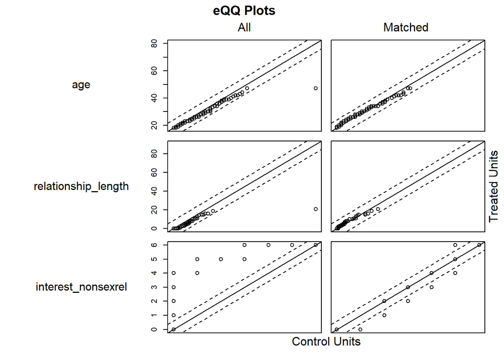

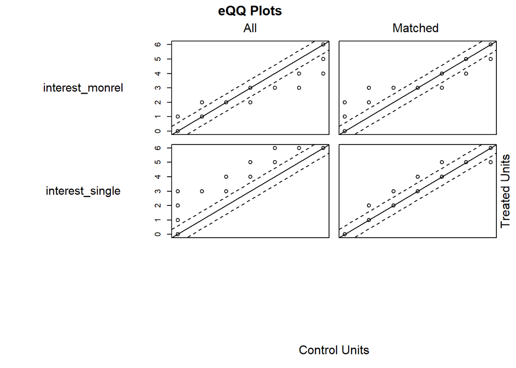

```r
# Q-Q plot
plot(nnm_add, type = "qq", interactive = FALSE, which.xs = c("age", "relationship_length", "interest_nonsexrel", "interest_monrel", "interest_single"))
```

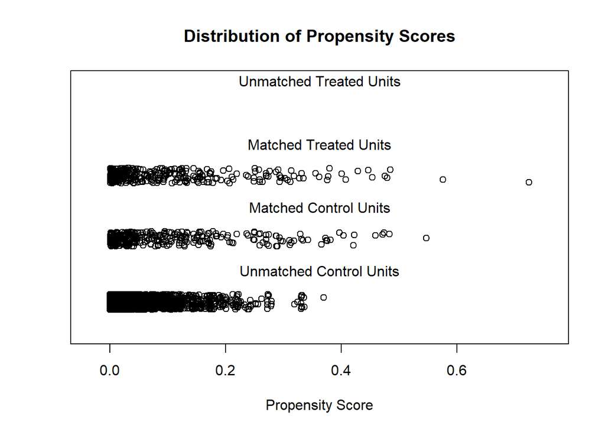

```r
# looks better after matching

# Jitter plot
plot(nnm_add, type = "jitter", interactive = FALSE)
```

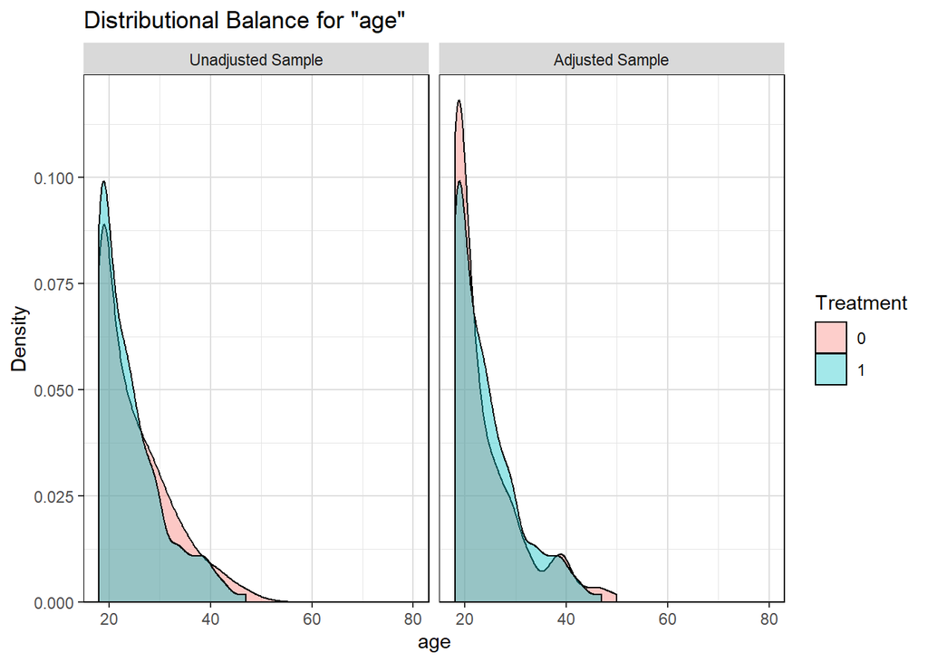

```r
# one observation in treated sample has a higher propensity score than any of the control units; however, most observations seem to fall within the area of common support

# distributional density/histogram
bal.plot(nnm_add, var.name = "age", which = "both", grid = T)
```

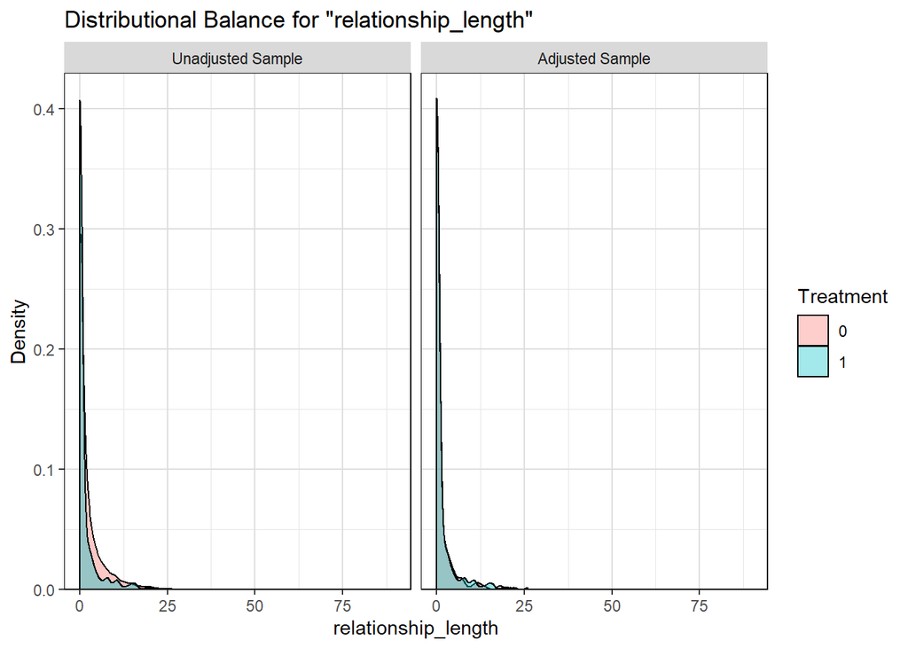

```r
bal.plot(nnm_add, var.name = "relationship_length", which = "both", grid = T)
```

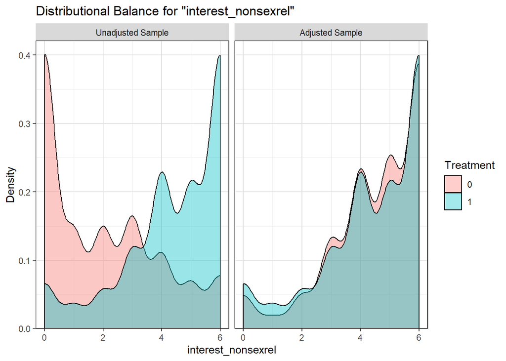

```r
bal.plot(nnm_add, var.name = "interest_nonsexrel", which = "both", grid = T)
```

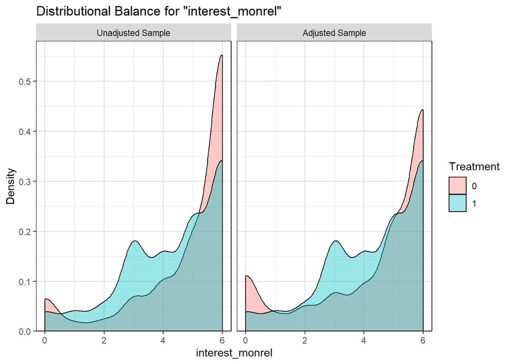

```r
bal.plot(nnm_add, var.name = "interest_monrel", which = "both", grid = T)
```

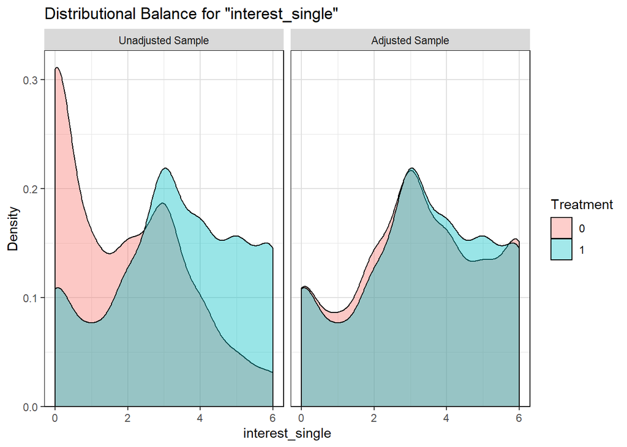

```r
bal.plot(nnm_add, var.name = "interest_single", which = "both", grid = T)
```

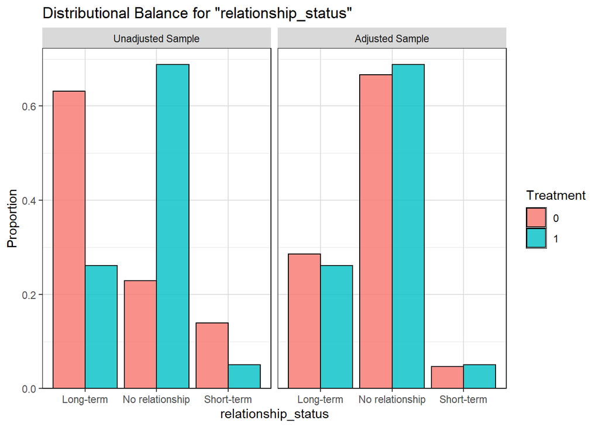

```r
bal.plot(nnm_add, var.name = "relationship_status", which = "both", grid = T)
```

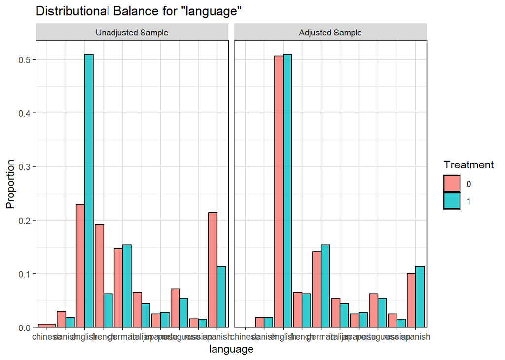

```r
bal.plot(nnm_add, var.name = "language", which = "both", grid = T)
```

[figure not shown]

```r
bal.plot(nnm_add, var.name = "country", which = "both", grid = T) # not readable
```

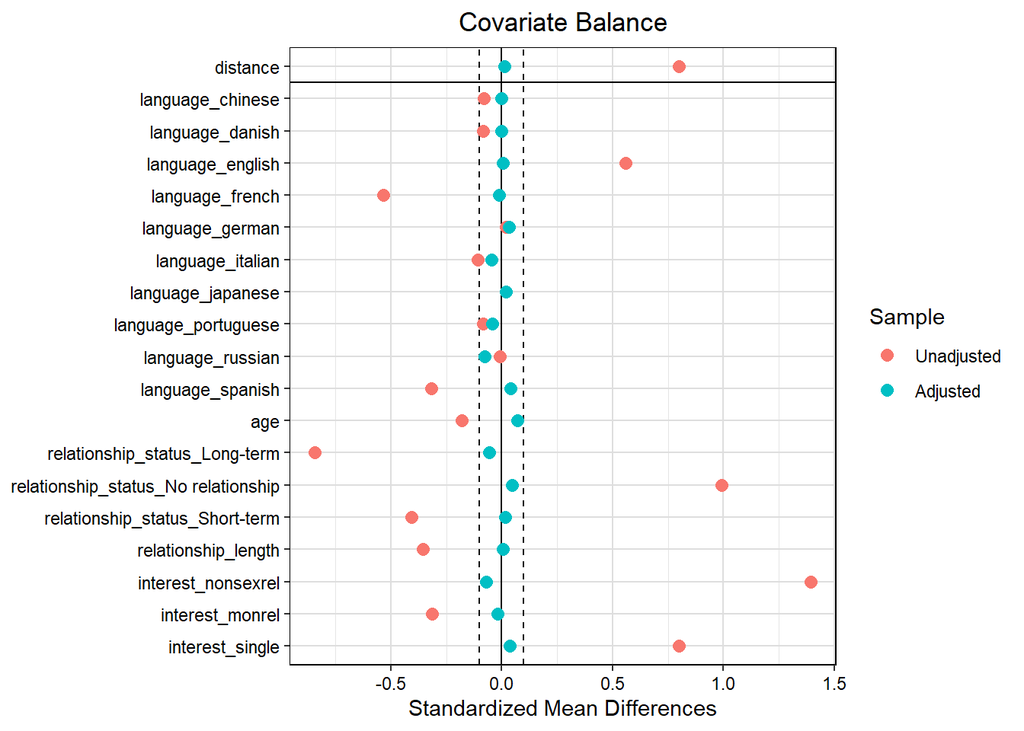

```r
# remove country variable for love plot
nnm_add_without_country = nnm_add
nnm_add_without_country$X[c("country")] <- NULL

love.plot(bal.tab(nnm_add_without_country, m.threshold = 0.1),
          stat = "mean.diffs",
          grid = T,
          stars = "raw",
          abs = F,
          binary = "std")
```

[figure not shown]

```r
## love plot using alternate variable names
# Using alternate variable names
v <- data.frame(old = c("distance", "language_chinese", "language_japanese", "language_german","language_english",
                        "language_italian", "language_danish", "language_spanish", "language_russian",
                        "language_portuguese", "language_french", "age", "relationship_status_Long-term",
                        "relationship_status_No relationship", "relationship_status_Short-term",
                        "relationship_length", "interest_nonsexrel", "interest_monrel", "interest_single"),
                new = c("Propensity scores", "Chinese", "Japanese", "German", "English", "Italian", "Danish",
                        "Spanish", "Russian", "Portuguese", "French", "Long-term relationship", "No relationship",
                        "Dating/Sexual Relationship","Age",  "Relationship length", "Interest non-sexual,
                        romantic relationships", "Interest monogamous relationships", "Interest single"))

love.plot(bal.tab(nnm_add_without_country, m.threshold = 0.1, binary = "std"),
          stat = "mean.diffs",
          grid = T,
          stars = "raw",
          abs = F,
          sample.names = c("Before Matching", "After Matching"),
          var.names = v)
```

### Recalculate t-test for differences in partner preferences based on this psm sample controlling for having no interest in any long-term relationship

Sort data by subclass number within sexual_orientation (so that all asexual participants appear first sorted by subclass)

```r
data_add = nnm_add_data %>%
        group_by(sexual_orientation) %>%
        arrange(subclass, .by_group = TRUE)

typeof(data_add$sexual_orientation) # sexual_orientation is a factor
```

```
## [1] "integer"
```

```r
levels(data_add$sexual_orientation) # check factor level order
```

```
## [1] "Straight/Heterosexual" "Asexual"
```

```r
# for analyses, I reverse the factor levels so that 0 = Asexuals and 1 = Straight/Heterosexual
data_add$sexual_orientation =  factor(data_add$sexual_orientation,
                                             levels=rev(levels(data_add$sexual_orientation))) # reverse order of factor levels
levels(data_add$sexual_orientation) # check factor level order
```

```
## [1] "Asexual"               "Straight/Heterosexual"
```

#### Quick overview

```r
# mean
data_add %>% group_by(sexual_orientation) %>%
  summarise_at(c("pref_imp_ca",
                 "pref_imp_att",
                 "pref_imp_sexually_experienced",
                 "pref_imp_ks",
                 "pref_imp_fs",
                 "pref_imp_ei"), mean, na.rm = T)
```

```
## # A tibble: 2 x 7
##   sexual_orientation    pref_imp_ca pref_imp_att pref_imp_sexually_~ pref_imp_ks
##   <fct>                       <dbl>        <dbl>               <dbl>       <dbl>
## 1 Asexual                      3.91         3.18                1.32        5.47
## 2 Straight/Heterosexual        4.40         3.86                2.5         5.56
## # ... with 2 more variables: pref_imp_fs <dbl>, pref_imp_ei <dbl>
```

```r
# sd
data_add %>% group_by(sexual_orientation) %>%
  summarise_at(c("pref_imp_ca",
                 "pref_imp_att",
                 "pref_imp_sexually_experienced",
                 "pref_imp_ks",
                 "pref_imp_fs",
                 "pref_imp_ei"), sd, na.rm = T)
```

```
## # A tibble: 2 x 7
##   sexual_orientation    pref_imp_ca pref_imp_att pref_imp_sexually_~ pref_imp_ks
##   <fct>                       <dbl>        <dbl>               <dbl>       <dbl>
## 1 Asexual                     1.16          1.52                1.81       0.662
## 2 Straight/Heterosexual       0.997         1.27                2.02       0.569
## # ... with 2 more variables: pref_imp_fs <dbl>, pref_imp_ei <dbl>
```

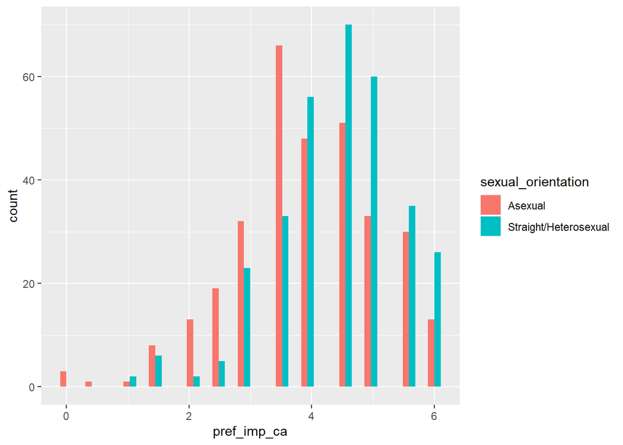

```r
# Visualize
# confident-assertive
ggplot(data_add, aes(x = pref_imp_ca, fill = sexual_orientation)) +
  geom_histogram(position = "dodge")
```

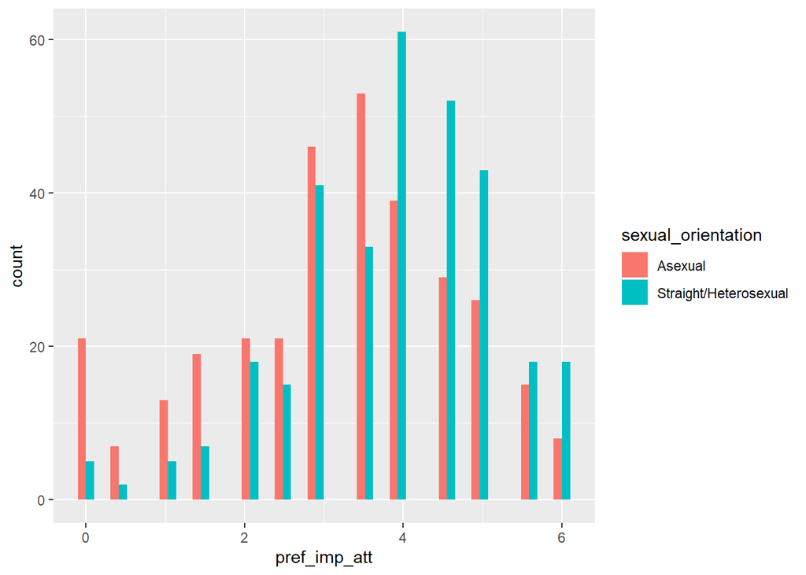

```r
# attractive
ggplot(data_add, aes(x = pref_imp_att, fill = sexual_orientation)) +
  geom_histogram(position = "dodge")
```

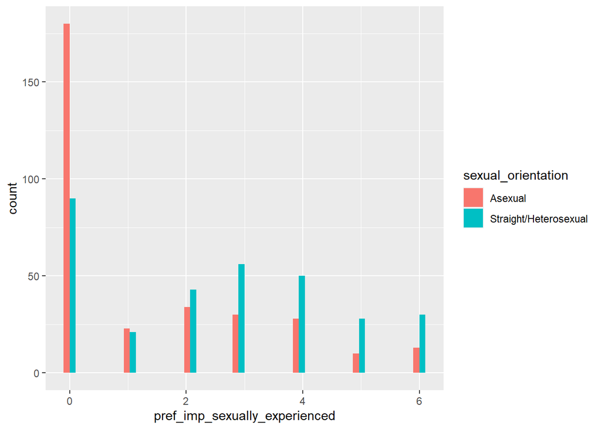

```r
# sexually experienced
ggplot(data_add, aes(x = pref_imp_sexually_experienced, fill = sexual_orientation)) +
  geom_histogram(position = "dodge")
```

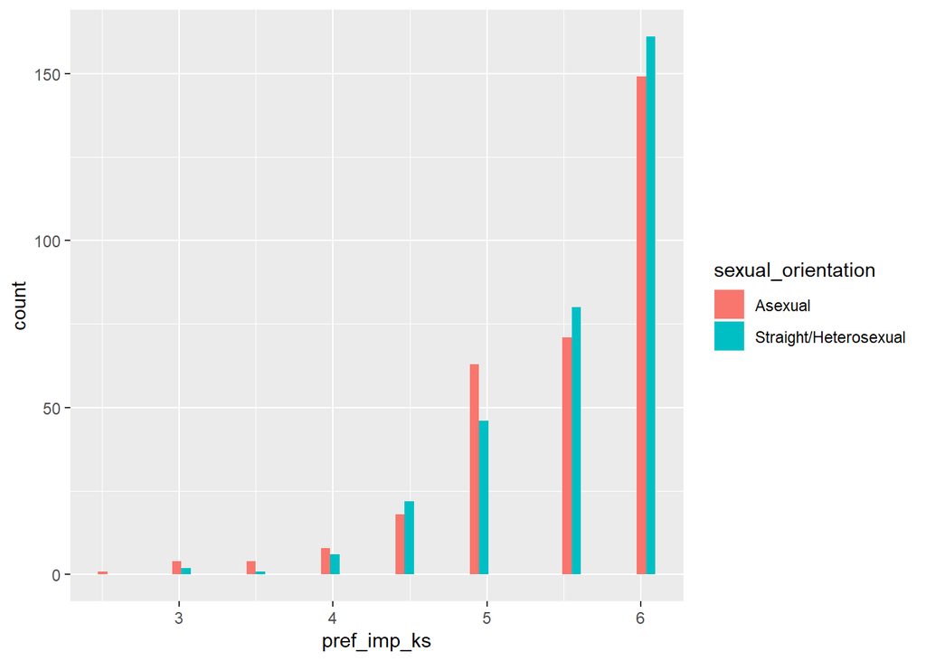

```r
# kind-supportive
ggplot(data_add, aes(x = pref_imp_ks, fill = sexual_orientation)) +
  geom_histogram(position = "dodge")
```

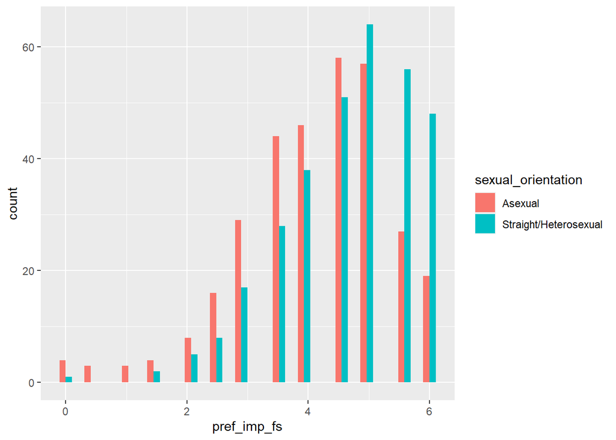

```r
# financially secure-successful
ggplot(data_add, aes(x = pref_imp_fs, fill = sexual_orientation)) +
  geom_histogram(position = "dodge")
```

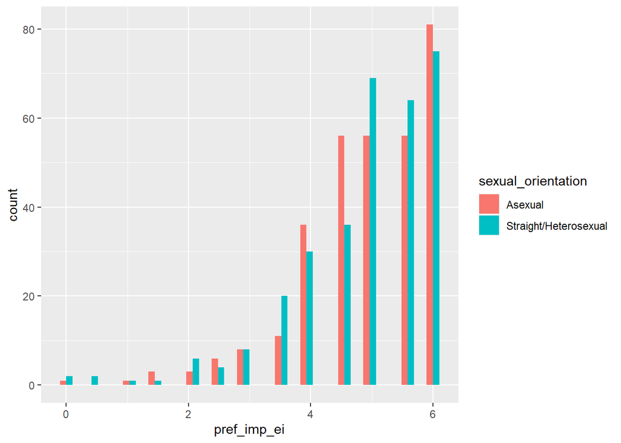

```r
# educated-intelligent
ggplot(data_add, aes(x = pref_imp_ei, fill = sexual_orientation)) +
  geom_histogram(position = "dodge")
```

#### Confident-assertive

```r
t.test(pref_imp_ca ~ sexual_orientation,
       data = data_add,
       alternative = "less",
       paired = TRUE)
```

```
##
##  Paired t-test
##
## data:  pref_imp_ca by sexual_orientation
## t = -6.0514, df = 317, p-value = 2.024e-09
## alternative hypothesis: true difference in means is less than 0
## 95 percent confidence interval:
##       -Inf -0.356833
## sample estimates:
## mean of the differences
##               -0.490566
```

```r
# effect size
effsize::cohen.d(pref_imp_ca ~ sexual_orientation, data = data_add, paired = T)
```

```
##
## Cohen's d
##
## d estimate: -0.4536739 (small)
## 95 percent confidence interval:
##      lower      upper
## -0.6082829 -0.2990649
```

#### Attractive

```r
t.test(pref_imp_att ~ sexual_orientation,
       data = data_add,
       alternative = "less",
       paired = TRUE)
```

```
##
##  Paired t-test
##
## data:  pref_imp_att by sexual_orientation
## t = -6.1419, df = 317, p-value = 1.22e-09
## alternative hypothesis: true difference in means is less than 0
## 95 percent confidence interval:
##        -Inf -0.5025549
## sample estimates:
## mean of the differences
##              -0.6871069
```

```r
# effect size
effsize::cohen.d(pref_imp_att ~ sexual_orientation, data = data_add, paired = T)
```

```
##
## Cohen's d
##
## d estimate: -0.4909911 (small)
## 95 percent confidence interval:
##      lower      upper
## -0.6571642 -0.3248180
```

#### Sexually experienced

```r
t.test(pref_imp_sexually_experienced ~ sexual_orientation,
       data = data_add,
       alternative = "less",
       paired = TRUE)
```

```
##
##  Paired t-test
##
## data:  pref_imp_sexually_experienced by sexual_orientation
## t = -8.3453, df = 317, p-value = 1.11e-15
## alternative hypothesis: true difference in means is less than 0
## 95 percent confidence interval:
##        -Inf -0.9436118
## sample estimates:
## mean of the differences
##               -1.176101
```

```r
# effect size
effsize::cohen.d(pref_imp_sexually_experienced ~ sexual_orientation, data = data_add, paired = T)
```

```
##
## Cohen's d
##
## d estimate: -0.6135778 (medium)
## 95 percent confidence interval:
##      lower      upper
## -0.7709612 -0.4561944
```

#### Exploratory analyses

##### Kind-supportive

```r
t.test(pref_imp_ks ~ sexual_orientation,
       data = data_add,
       alternative = "two.sided",
       paired = TRUE)
```

```
##
##  Paired t-test
##
## data:  pref_imp_ks by sexual_orientation
## t = -1.7283, df = 317, p-value = 0.0849
## alternative hypothesis: true difference in means is not equal to 0
## 95 percent confidence interval:
##  -0.18492139  0.01196542
## sample estimates:
## mean of the differences
##             -0.08647799
```

```r
# effect size
effsize::cohen.d(pref_imp_ks ~ sexual_orientation, data = data_add, paired = T)
```

```
##
## Cohen's d
##
## d estimate: -0.140195 (negligible)
## 95 percent confidence interval:
##       lower       upper
## -0.30026349  0.01987345
```

##### Financially secure-successful

```r
t.test(pref_imp_fs ~ sexual_orientation,
       data = data_add,
       alternative = "two.sided",
       paired = TRUE)
```

```
##
##  Paired t-test
##
## data:  pref_imp_fs by sexual_orientation
## t = -6.3585, df = 317, p-value = 7.101e-10
## alternative hypothesis: true difference in means is not equal to 0
## 95 percent confidence interval:
##  -0.7391255 -0.3898054
## sample estimates:
## mean of the differences
##              -0.5644654
```

```r
# effect size
effsize::cohen.d(pref_imp_fs ~ sexual_orientation, data = data_add, paired = T)
```

```
##
## Cohen's d
##
## d estimate: -0.4973607 (small)
## 95 percent confidence interval:
##      lower      upper
## -0.6601847 -0.3345367
```

##### Educated-intelligent

```r
t.test(pref_imp_ei ~ sexual_orientation,
       data = data_add,
       alternative = "two.sided",
       paired = TRUE)
```

```
##
##  Paired t-test
##
## data:  pref_imp_ei by sexual_orientation
## t = 0.38698, df = 317, p-value = 0.699
## alternative hypothesis: true difference in means is not equal to 0
## 95 percent confidence interval:
##  -0.1348560  0.2008937
## sample estimates:
## mean of the differences
##              0.03301887
```

```r
# effect size
effsize::cohen.d(pref_imp_ei ~ sexual_orientation, data = data_add, paired = T)
```

```
##
## Cohen's d
##
## d estimate: 0.03055579 (negligible)
## 95 percent confidence interval:
##      lower      upper
## -0.1245353  0.1856469
```

### Create forest plot

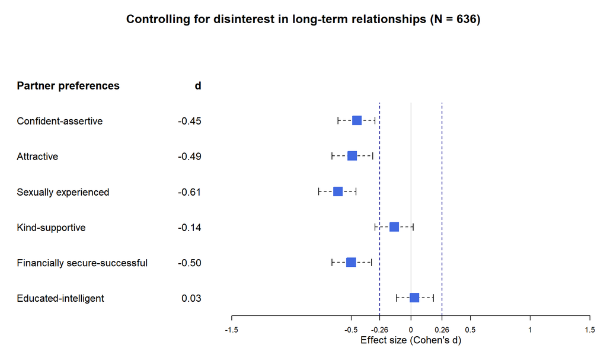

```r
base_data_add <- tibble(mean  = c(-0.45, -0.49, -0.61, -0.14, -0.50, 0.03),
                    lower = c(-0.61, -0.66, -0.77, -0.30, -0.66, -0.12),
                    upper = c(-0.30, -0.32, -0.46, 0.02, -0.33, 0.19),
                    Partner_preferences = c("Confident-assertive", "Attractive",
                                            "Sexually experienced", "Kind-supportive",
                                            "Financially secure-successful", "Educated-intelligent"),
                    d = c("-0.45", "-0.49", "-0.61", "-0.14", "-0.50", "0.03"))

header_add <- tibble(Partner_preferences = c("", "Partner preferences"),
                d = c("", "d"),
                 summary = TRUE)

partner_preferences_add <- bind_rows(header_add,
                                base_data_add)



partner_preferences_add %>%
  forestplot(labeltext = c(Partner_preferences, d),
             graph.pos = 3,
              clip = c(-1,2),
             lty.ci = 2,
             boxsize = .25,
              is.summary = summary,
              grid = structure(c(-.26, .26),
                              gp = gpar(lty = 2, col = "darkblue")),
             xticks = c(-1.5, -.26, -0.5,0, .26, .5, 1, 1.5),
             xlab = "Effect size (Cohen's d)",
             txt_gp = fpTxtGp(ticks=gpar(cex=.75), xlab=gpar(cex=1)),
             col = fpColors(box = "royalblue",
                            line = "black",
                            summary = "royalblue"),
             title = "Controlling for disinterest in long-term relationships (N = 636)",
             graphwidth = unit(150, "mm"))
```

## 2. PSM including interest in purely sexual relationships

Check for missings in covariates to be matched - psm cannot handle missings - covariates: language, age, country, relationship status, relationship length - additionally match for: interest_nonsexrel, interest_monrel, interest_single & interest_hookups

```r
# MatchIt does not allow missing values
data_main_nomiss_add2 <- data_main %>% select(id, language, age, sex, country, relationship_status,
                                              relationship_length, sexual_orientation,
                                              pref_imp_ks, pref_imp_att, pref_imp_fs, pref_imp_ca,
                                              pref_imp_ei, pref_imp_sexually_experienced,
                                              interest_nonsexrel, interest_monrel, interest_single,
                                              interest_hookups) %>%
                                  na.omit()

table(is.na(data_main_nomiss_add2)) # no more NAs in data set
```

```
##
##  FALSE
## 677304
```

Check if correct variable type

```r
typeof(data_main_nomiss_add2$sexual_orientation) # is variable of type character, but for PSM it needs to be a factor
```

```
## [1] "character"
```

```r
data_main_nomiss_add2$sexual_orientation = as.factor(data_main_nomiss_add2$sexual_orientation) # convert to factor
levels(data_main_nomiss_add2$sexual_orientation) # check levels of factor
```

```
## [1] "Asexual"               "Straight/Heterosexual"
```

```r
data_main_nomiss_add2$sexual_orientation = factor(data_main_nomiss_add2$sexual_orientation,
                                             levels=rev(levels(data_main_nomiss_add2$sexual_orientation))) # reverse order of factor levels
levels(data_main_nomiss_add2$sexual_orientation) # check factor level order
```

```
## [1] "Straight/Heterosexual" "Asexual"
```

### Matching with NNM

```r
nnm_add2 <- matchit(sexual_orientation ~ language + age + country + relationship_status +
                      relationship_length + interest_nonsexrel + interest_monrel +
                      interest_single + interest_hookups,
                    method = "nearest", data = data_main_nomiss_add2)

nnm_add2_data <- match.data(nnm_add2)

nrow(nnm_add2_data) # 636 observations
```

```
## [1] 636
```

```r
table(nnm_add2_data$subclass) # data includes only pairs of two observations
```

```
##
##   1   2   3   4   5   6   7   8   9  10  11  12  13  14  15  16  17  18  19  20
##   2   2   2   2   2   2   2   2   2   2   2   2   2   2   2   2   2   2   2   2
##  21  22  23  24  25  26  27  28  29  30  31  32  33  34  35  36  37  38  39  40
##   2   2   2   2   2   2   2   2   2   2   2   2   2   2   2   2   2   2   2   2
##  41  42  43  44  45  46  47  48  49  50  51  52  53  54  55  56  57  58  59  60
##   2   2   2   2   2   2   2   2   2   2   2   2   2   2   2   2   2   2   2   2
##  61  62  63  64  65  66  67  68  69  70  71  72  73  74  75  76  77  78  79  80
##   2   2   2   2   2   2   2   2   2   2   2   2   2   2   2   2   2   2   2   2
##  81  82  83  84  85  86  87  88  89  90  91  92  93  94  95  96  97  98  99 100
##   2   2   2   2   2   2   2   2   2   2   2   2   2   2   2   2   2   2   2   2
## 101 102 103 104 105 106 107 108 109 110 111 112 113 114 115 116 117 118 119 120
##   2   2   2   2   2   2   2   2   2   2   2   2   2   2   2   2   2   2   2   2
## 121 122 123 124 125 126 127 128 129 130 131 132 133 134 135 136 137 138 139 140
##   2   2   2   2   2   2   2   2   2   2   2   2   2   2   2   2   2   2   2   2
```

[output cut: 18 more lines]

```r
dim(nnm_add2_data) # 636 observations and 21 variables
```

```
## [1] 636  21
```

### Check balance

```r
summary_nnm_add2 = summary(nnm_add2, standardize = T)
print(summary_nnm_add2)
```

```
##
## Call:
## matchit(formula = sexual_orientation ~ language + age + country +
##     relationship_status + relationship_length + interest_nonsexrel +
##     interest_monrel + interest_single + interest_hookups, data = data_main_nomiss_add2,
##     method = "nearest")
##
## Summary of Balance for All Data:
##                                         Means Treated Means Control
## distance                                       0.1307        0.0074
## languagechinese                                0.0000        0.0064
## languagedanish                                 0.0189        0.0304
## languageenglish                                0.5094        0.2302
## languagefrench                                 0.0629        0.1923
## languagegerman                                 0.1541        0.1470
## languageitalian                                0.0440        0.0658
## languagejapanese                               0.0283        0.0252
## languageportuguese                             0.0535        0.0725
## languagerussian                                0.0157        0.0165
## languagespanish                                0.1132        0.2137
## age                                           24.0660       25.2242
## countryAfghanistan                             0.0000        0.0001
## countryAlbania                                 0.0000        0.0001
## countryAlgeria                                 0.0031        0.0003
## countryAndorra                                 0.0000        0.0002
## countryAngola                                  0.0000        0.0001
## countryAntigua and Barbuda                     0.0000        0.0001
## countryArgentina                               0.0220        0.0152
## countryArmenia                                 0.0000        0.0001
## countryAruba                                   0.0000        0.0001
## countryAustralia                               0.0346        0.0109
## countryAustria                                 0.0094        0.0127
## countryAzerbaijan                              0.0000        0.0000
## countryBahamas, The                            0.0000        0.0001
## countryBahrain                                 0.0000        0.0001
## countryBarbados                                0.0000        0.0001
## countryBelarus                                 0.0000        0.0010
## countryBelgium                                 0.0000        0.0091
## countryBelize                                  0.0000        0.0001
## countryBenin                                   0.0000        0.0000
```

[output cut: 1437 more lines]

```
## relationship_statusLong-term                95.8
## relationship_statusNo relationship          96.6
## relationship_statusShort-term              100.0
## relationship_length                         94.1
## interest_nonsexrel                          96.4
## interest_monrel                             29.2
## interest_single                             86.6
## interest_hookups                            92.5
##
## Sample Sizes:
##           Control Treated
## All         37310     318
## Matched       318     318
## Unmatched   36992       0
## Discarded       0       0
```

```r
tail(summary_nnm_add2$sum.matched) #look at balance properties for interest variables
```

```
##                               Means Treated Means Control Std. Mean Diff.
## relationship_statusShort-term    0.05031447    0.05031447     0.000000000
## relationship_length              1.16981132    1.26100629    -0.028681245
## interest_nonsexrel               4.37735849    4.44339623    -0.037776642
## interest_monrel                  4.35220126    4.34276730     0.005660384
## interest_single                  3.31761006    3.38050314    -0.033505894
## interest_hookups                 0.66981132    0.65723270     0.009427485
##                               Var. Ratio   eCDF Mean   eCDF Max Std. Pair Dist.
## relationship_statusShort-term         NA 0.000000000 0.00000000       0.1006289
## relationship_length            0.6592488 0.003813729 0.01572327       0.6656027
## interest_nonsexrel             1.0546945 0.009433962 0.01886792       0.7105606
## interest_monrel                0.5771705 0.080413297 0.15723270       1.0849070
## interest_single                0.9315759 0.010781671 0.04402516       0.9281133
## interest_hookups               1.0230075 0.006289308 0.01886792       0.6976339
```

```r
bal.tab(nnm_add2, m.threshold = 0.1, un = T, binary = "std") #smd
```

```
## Call
##  matchit(formula = sexual_orientation ~ language + age + country +
##     relationship_status + relationship_length + interest_nonsexrel +
##     interest_monrel + interest_single + interest_hookups, data = data_main_nomiss_add2,
##     method = "nearest")
##
## Balance Measures
##                                              Type Diff.Un Diff.Adj
## distance                                 Distance  0.8186   0.0194
## language_chinese                           Binary -0.0805   0.0000
## language_danish                            Binary -0.0851   0.0231
## language_english                           Binary  0.5586   0.0000
## language_french                            Binary -0.5329  -0.0648
## language_german                            Binary  0.0197   0.0523
## language_italian                           Binary -0.1063  -0.0460
## language_japanese                          Binary  0.0187   0.1327
## language_portuguese                        Binary -0.0846  -0.0419
## language_russian                           Binary -0.0065   0.0253
## language_spanish                           Binary -0.3172  -0.0397
## age                                       Contin. -0.1811   0.0143
## country_Afghanistan                        Binary -0.0074   0.0000
## country_Albania                            Binary -0.0090   0.0000
## country_Algeria                            Binary  0.0504   0.0000
## country_Andorra                            Binary -0.0147   0.0000
## country_Angola                             Binary -0.0074   0.0000
## country_Antigua and Barbuda                Binary -0.0104   0.0000
## country_Argentina                          Binary  0.0465  -0.1286
## country_Armenia                            Binary -0.0104   0.0000
## country_Aruba                              Binary -0.0074   0.0000
## country_Australia                          Binary  0.1299   0.0516
## country_Austria                            Binary -0.0338   0.0000
## country_Azerbaijan                         Binary -0.0052   0.0000
## country_Bahamas, The                       Binary -0.0104   0.0000
## country_Bahrain                            Binary -0.0090   0.0000
## country_Barbados                           Binary -0.0104   0.0000
## country_Belarus                            Binary -0.0312   0.0000
## country_Belgium                            Binary -0.0962   0.0000
## country_Belize                             Binary -0.0090   0.0000
## country_Benin                              Binary -0.0052   0.0000
## country_Bhutan                             Binary -0.0052   0.0000
```

[output cut: 335 more lines]

```
##
## Balance tally for mean differences
##                    count
## Balanced, <0.1       178
## Not Balanced, >0.1     5
##
## Variable with the greatest mean difference
##           Variable Diff.Adj        M.Threshold
##  language_japanese   0.1327 Not Balanced, >0.1
##
## Sample sizes
##           Control Treated
## All         37310     318
## Matched       318     318
## Unmatched   36992       0
```

```r
bal.tab(nnm_add2, v.threshold = 2, un = T) #vr (can only be calculated for continuous variables)
```

```
## Call
##  matchit(formula = sexual_orientation ~ language + age + country +
##     relationship_status + relationship_length + interest_nonsexrel +
##     interest_monrel + interest_single + interest_hookups, data = data_main_nomiss_add2,
##     method = "nearest")
##
## Balance Measures
##                                              Type Diff.Un V.Ratio.Un Diff.Adj
## distance                                 Distance  0.8186    32.4365   0.0194
## language_chinese                           Binary -0.0805          .   0.0000
## language_danish                            Binary -0.0851          .   0.0231
## language_english                           Binary  0.5586          .   0.0000
## language_french                            Binary -0.5329          .  -0.0648
## language_german                            Binary  0.0197          .   0.0523
## language_italian                           Binary -0.1063          .  -0.0460
## language_japanese                          Binary  0.0187          .   0.1327
## language_portuguese                        Binary -0.0846          .  -0.0419
## language_russian                           Binary -0.0065          .   0.0253
## language_spanish                           Binary -0.3172          .  -0.0397
## age                                       Contin. -0.1811     0.7842   0.0143
## country_Afghanistan                        Binary -0.0074          .   0.0000
## country_Albania                            Binary -0.0090          .   0.0000
## country_Algeria                            Binary  0.0504          .   0.0000
## country_Andorra                            Binary -0.0147          .   0.0000
## country_Angola                             Binary -0.0074          .   0.0000
## country_Antigua and Barbuda                Binary -0.0104          .   0.0000
## country_Argentina                          Binary  0.0465          .  -0.1286
## country_Armenia                            Binary -0.0104          .   0.0000
## country_Aruba                              Binary -0.0074          .   0.0000
## country_Australia                          Binary  0.1299          .   0.0516
## country_Austria                            Binary -0.0338          .   0.0000
## country_Azerbaijan                         Binary -0.0052          .   0.0000
## country_Bahamas, The                       Binary -0.0104          .   0.0000
## country_Bahrain                            Binary -0.0090          .   0.0000
## country_Barbados                           Binary -0.0104          .   0.0000
## country_Belarus                            Binary -0.0312          .   0.0000
## country_Belgium                            Binary -0.0962          .   0.0000
## country_Belize                             Binary -0.0090          .   0.0000
## country_Benin                              Binary -0.0052          .   0.0000
## country_Bhutan                             Binary -0.0052          .   0.0000
```

[output cut: 335 more lines]

```
##
## Balance tally for variance ratios
##                  count
## Balanced, <2         7
## Not Balanced, >2     0
##
## Variable with the greatest variance ratio
##         Variable V.Ratio.Adj  V.Threshold
##  interest_monrel      0.5772 Balanced, <2
##
## Sample sizes
##           Control Treated
## All         37310     318
## Matched       318     318
## Unmatched   36992       0
```

No asexual unmatched. Based on smds 5 covariates not balanced (country_Singapore, country_Japan, country_France, country_Argentina, language_japanese). Based on vr, all continuous covariates balanced.

### Visualize

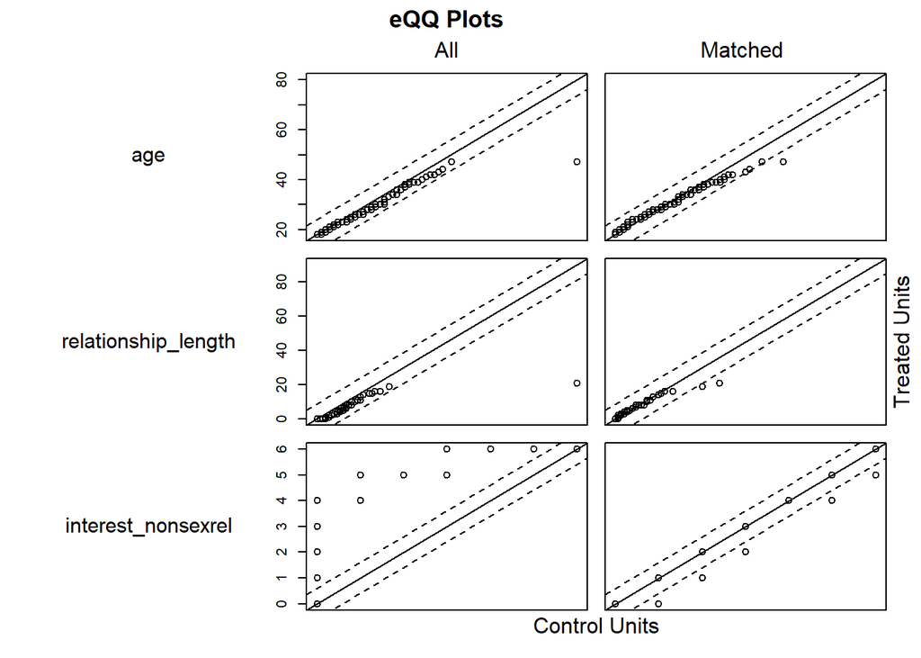

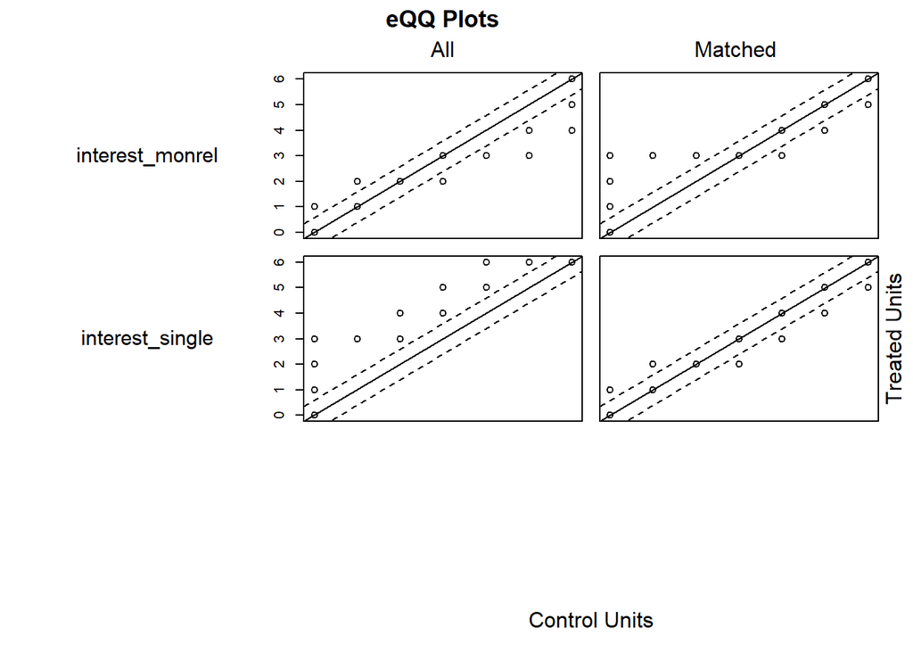

```r
# Q-Q plot
plot(nnm_add2, type = "qq", interactive = FALSE, which.xs = c("age", "relationship_length", "interest_nonsexrel", "interest_monrel", "interest_single"))
```

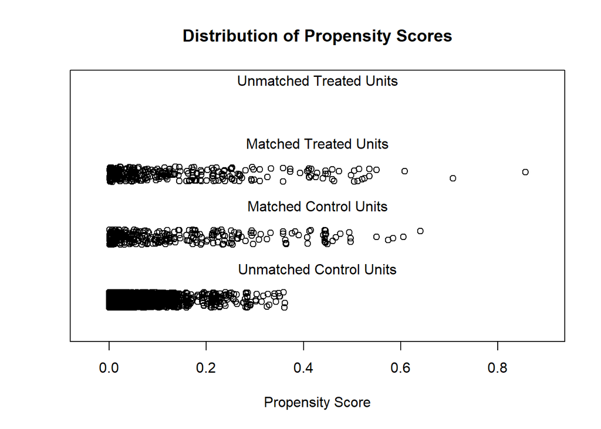

```r
# looks better after matching

# Jitter plot
plot(nnm_add2, type = "jitter", interactive = FALSE)
```

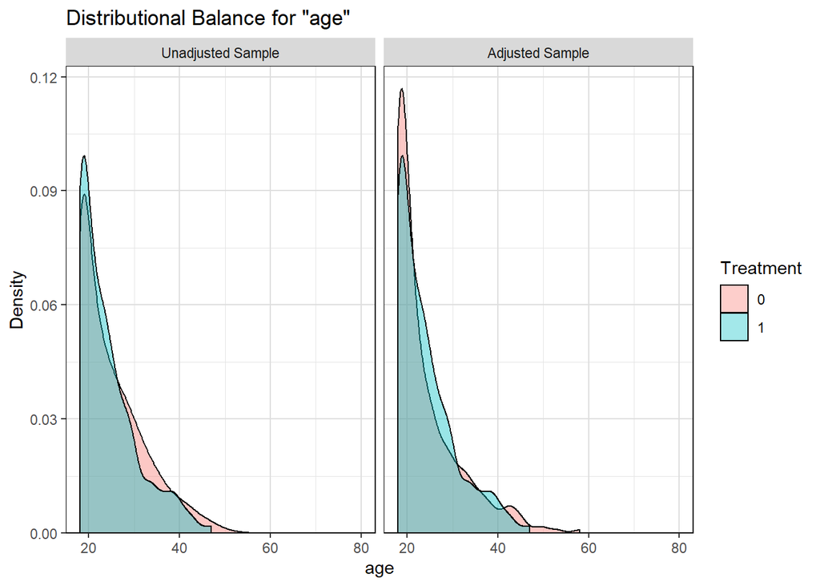

```r
# two observations in treated sample has a higher propensity score than any of the control units; however, most observations seem to fall within the area of common support

# distributional density/histogram
bal.plot(nnm_add2, var.name = "age", which = "both", grid = T)
```

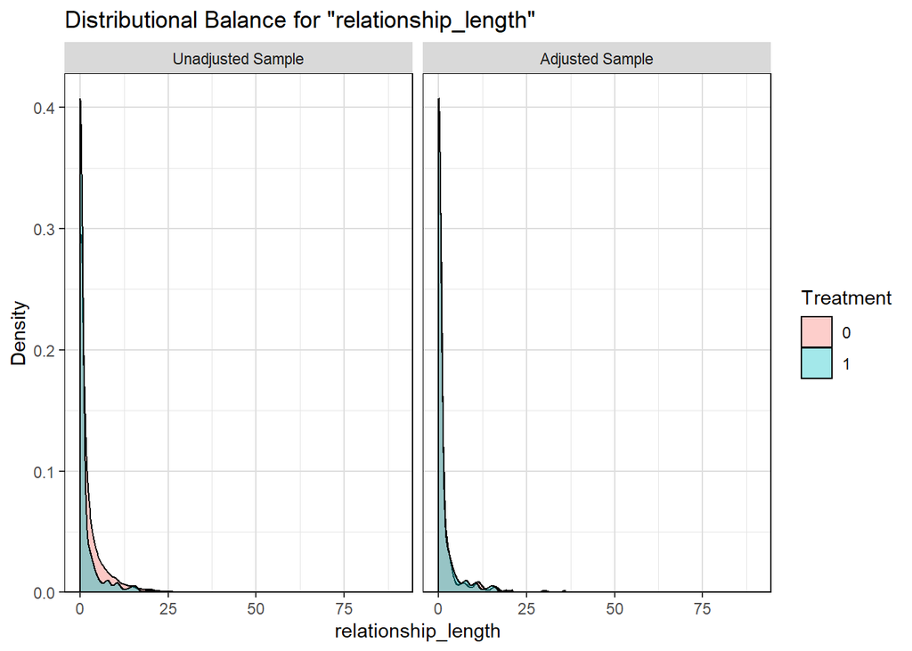

```r
bal.plot(nnm_add2, var.name = "relationship_length", which = "both", grid = T)
```

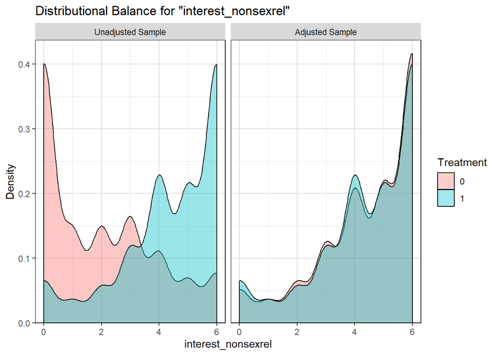

```r
bal.plot(nnm_add2, var.name = "interest_nonsexrel", which = "both", grid = T)
```

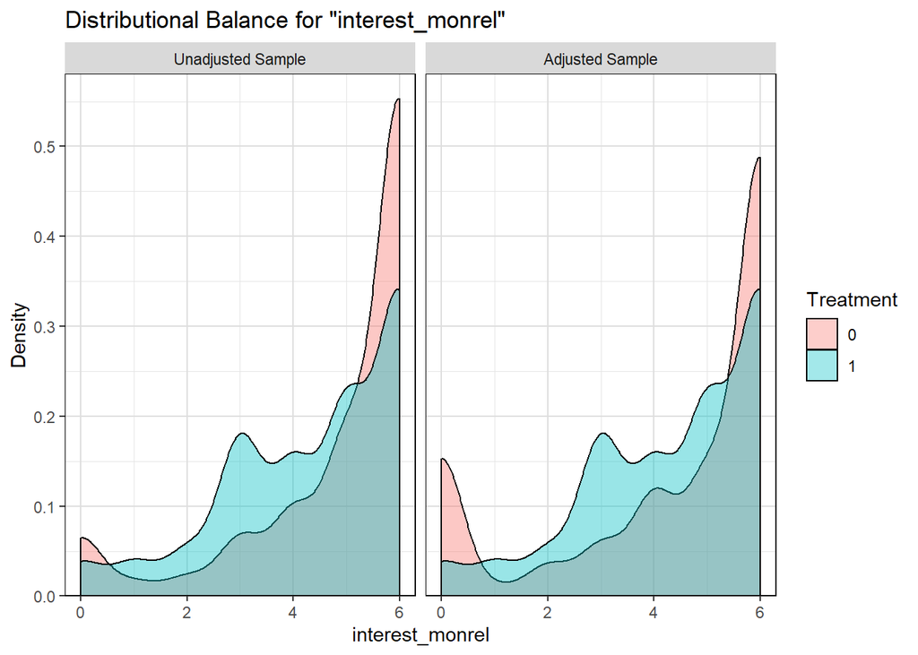

```r
bal.plot(nnm_add2, var.name = "interest_monrel", which = "both", grid = T)
```

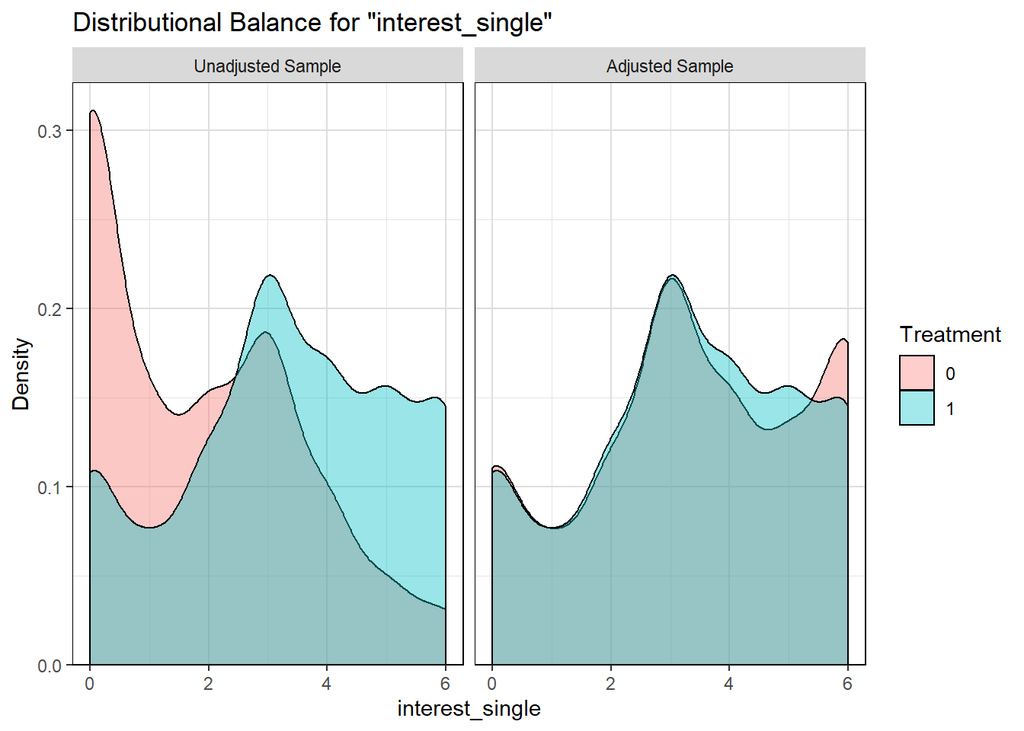

```r
bal.plot(nnm_add2, var.name = "interest_single", which = "both", grid = T)
```

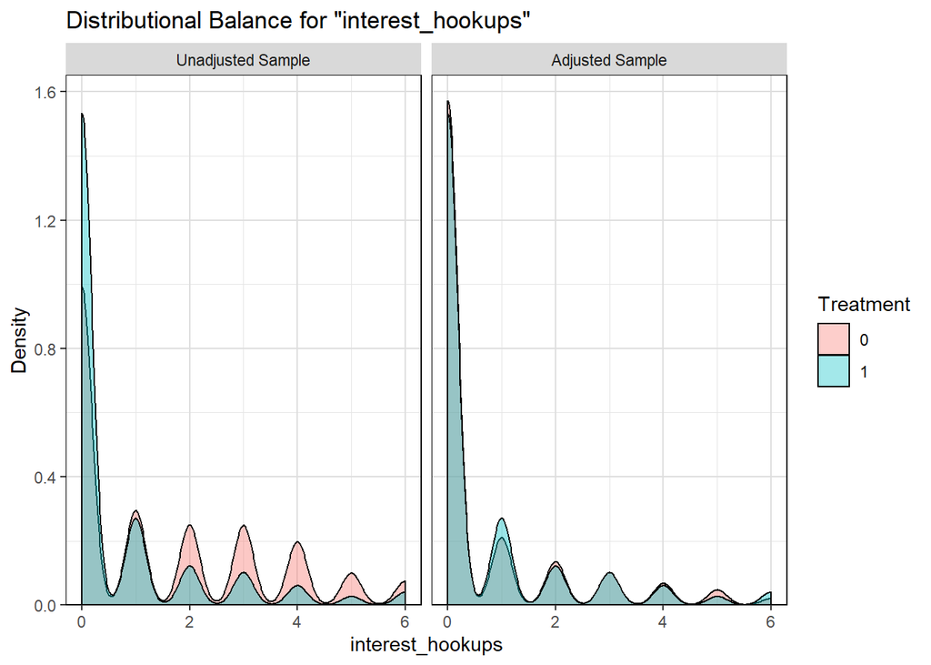

```r
bal.plot(nnm_add2, var.name = "interest_hookups", which = "both", grid = T)
```

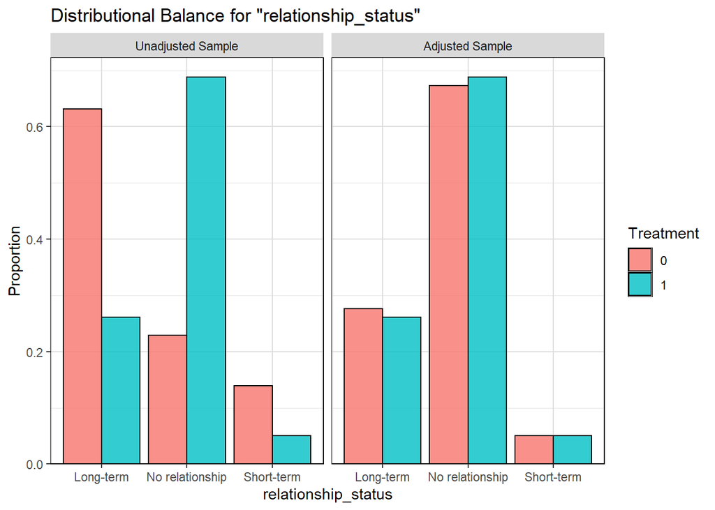

```r
bal.plot(nnm_add2, var.name = "relationship_status", which = "both", grid = T)
```

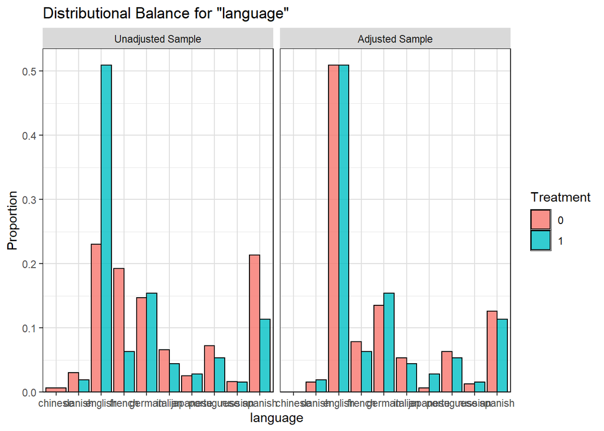

```r
bal.plot(nnm_add2, var.name = "language", which = "both", grid = T)
```

[figure not shown]

```r
bal.plot(nnm_add2, var.name = "country", which = "both", grid = T) # not readable
```

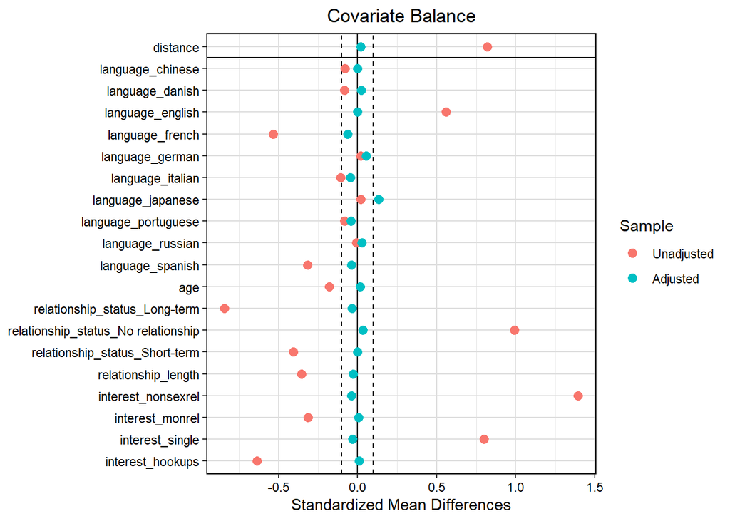

```r
# remove country variable for love plot
nnm_add2_without_country = nnm_add2
nnm_add2_without_country$X[c("country")] <- NULL

love.plot(bal.tab(nnm_add2_without_country, m.threshold = 0.1),
          stat = "mean.diffs",
          grid = T,
          stars = "raw",
          abs = F,
          binary = "std")
```

[figure not shown]

```r
## love plot using alternate variable names
# Using alternate variable names
v <- data.frame(old = c("distance", "language_chinese", "language_japanese", "language_german","language_english",
                        "language_italian", "language_danish", "language_spanish", "language_russian",
                        "language_portuguese", "language_french", "age", "relationship_status_Long-term",
                        "relationship_status_No relationship", "relationship_status_Short-term",
                        "relationship_length", "interest_nonsexrel", "interest_monrel", "interest_single",
                        "interest_hookups"),
                new = c("Propensity scores", "Chinese", "Japanese", "German", "English", "Italian", "Danish",
                        "Spanish", "Russian", "Portuguese", "French", "Long-term relationship", "No relationship",
                        "Dating/Sexual Relationship","Age",  "Relationship length", "Interest non-sexual,
                        romantic relationships", "Interest monogamous relationships", "Interest single",
                        "Interest sexual, non-romantic relationships"))

love.plot(bal.tab(nnm_add2_without_country, m.threshold = 0.1, binary = "std"),
          stat = "mean.diffs",
          grid = T,
          stars = "raw",
          abs = F,
          sample.names = c("Before Matching", "After Matching"),
          var.names = v)
```

### Recalculate t-test for differences in partner preferences based on this psm sample controlling for having no interest in any long-term relationship

Sort data by subclass number within sexual_orientation

```r
data_add2 = nnm_add2_data %>%
        group_by(sexual_orientation) %>%
        arrange(subclass, .by_group = TRUE)

levels(data_add2$sexual_orientation) # check factor level
```

```
## [1] "Straight/Heterosexual" "Asexual"
```

```r
# for analyses, I reverse the factor levels so that 0 = Asexuals and 1 = Straight/Heterosexual
data_add2$sexual_orientation =  factor(data_add2$sexual_orientation,
                                             levels=rev(levels(data_add2$sexual_orientation))) # reverse order of factor levels
levels(data_add2$sexual_orientation) # check factor level order
```

```
## [1] "Asexual"               "Straight/Heterosexual"
```

#### Quick overview

```r
# mean
data_add2 %>% group_by(sexual_orientation) %>%
  summarise_at(c("pref_imp_ca",
                 "pref_imp_att",
                 "pref_imp_sexually_experienced",
                 "pref_imp_ks",
                 "pref_imp_fs",
                 "pref_imp_ei"), mean, na.rm = T)
```

```
## # A tibble: 2 x 7
##   sexual_orientation    pref_imp_ca pref_imp_att pref_imp_sexually_~ pref_imp_ks
##   <fct>                       <dbl>        <dbl>               <dbl>       <dbl>
## 1 Asexual                      3.91         3.18                1.32        5.47
## 2 Straight/Heterosexual        4.43         3.79                2.02        5.61
## # ... with 2 more variables: pref_imp_fs <dbl>, pref_imp_ei <dbl>
```

```r
# sd
data_add2 %>% group_by(sexual_orientation) %>%
  summarise_at(c("pref_imp_ca",
                 "pref_imp_att",
                 "pref_imp_sexually_experienced",
                 "pref_imp_ks",
                 "pref_imp_fs",
                 "pref_imp_ei"), sd, na.rm = T)
```

```
## # A tibble: 2 x 7
##   sexual_orientation    pref_imp_ca pref_imp_att pref_imp_sexually_~ pref_imp_ks
##   <fct>                       <dbl>        <dbl>               <dbl>       <dbl>
## 1 Asexual                     1.16          1.52                1.81       0.662
## 2 Straight/Heterosexual       0.965         1.32                1.98       0.531
## # ... with 2 more variables: pref_imp_fs <dbl>, pref_imp_ei <dbl>
```

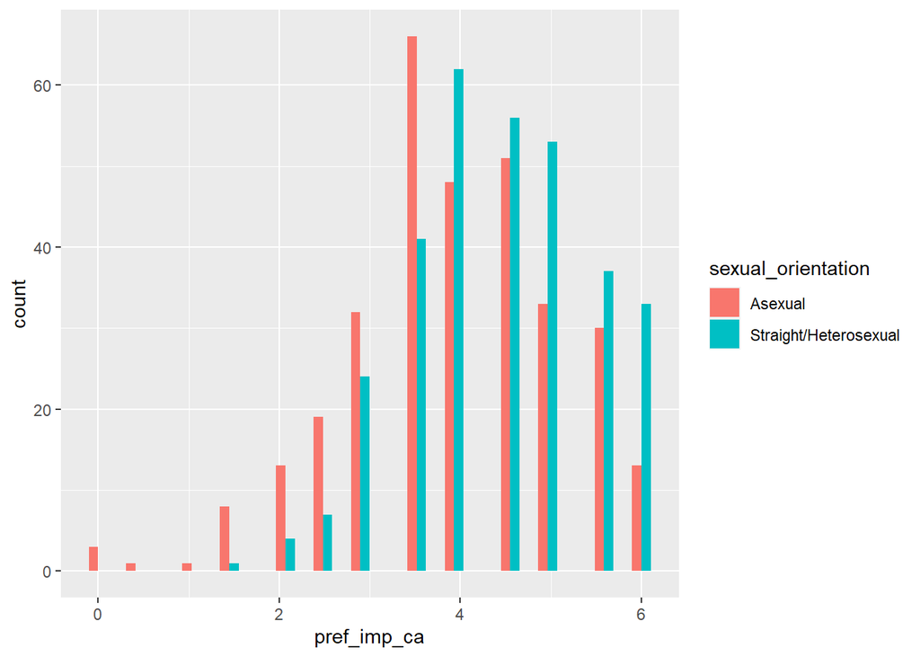

```r
# Visualize
# confident-assertive
ggplot(data_add2, aes(x = pref_imp_ca, fill = sexual_orientation)) +
  geom_histogram(position = "dodge")
```

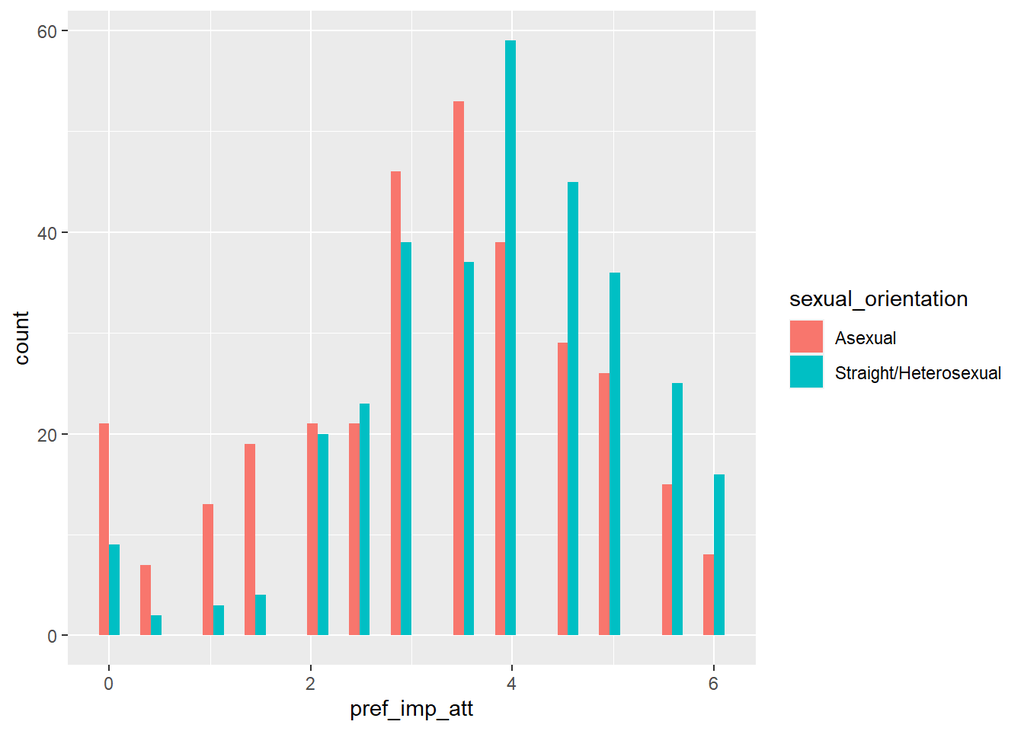

```r
# attractive
ggplot(data_add2, aes(x = pref_imp_att, fill = sexual_orientation)) +
  geom_histogram(position = "dodge")
```

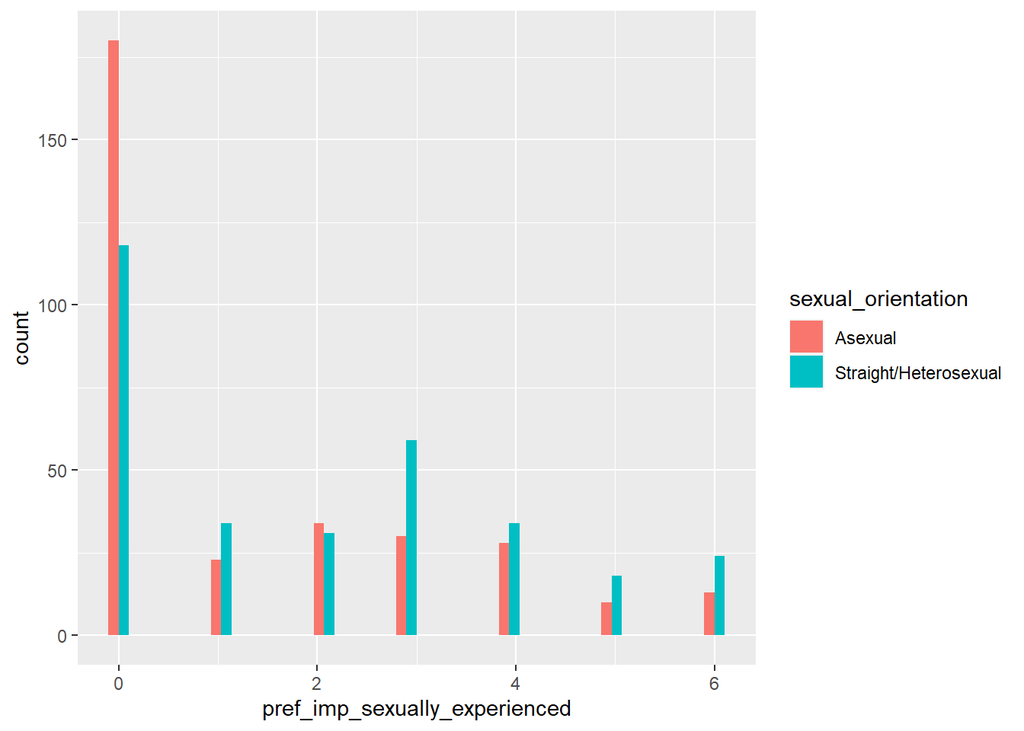

```r
# sexually experienced
ggplot(data_add2, aes(x = pref_imp_sexually_experienced, fill = sexual_orientation)) +
  geom_histogram(position = "dodge")
```

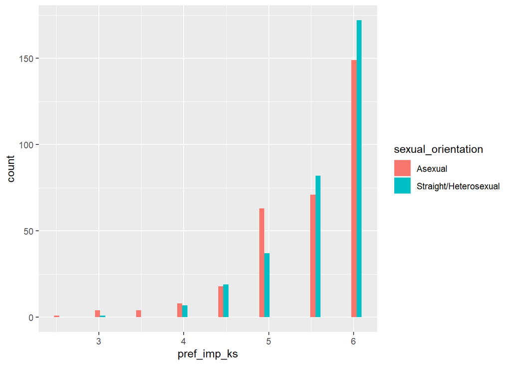

```r
# kind-supportive
ggplot(data_add2, aes(x = pref_imp_ks, fill = sexual_orientation)) +
  geom_histogram(position = "dodge")
```

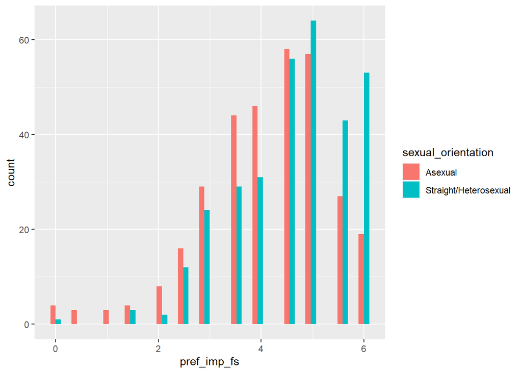

```r
# financially secure-successful
ggplot(data_add2, aes(x = pref_imp_fs, fill = sexual_orientation)) +
  geom_histogram(position = "dodge")
```

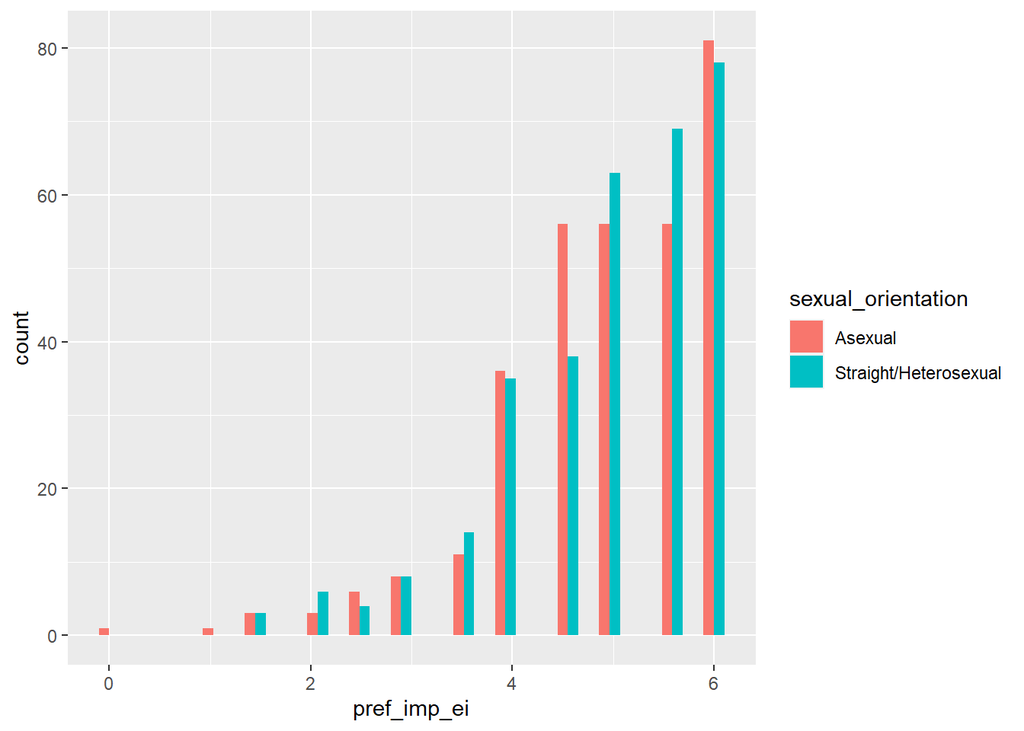

```r
# educated-intelligent
ggplot(data_add2, aes(x = pref_imp_ei, fill = sexual_orientation)) +
  geom_histogram(position = "dodge")
```

#### Confident-assertive

```r
t.test(pref_imp_ca ~ sexual_orientation,
       data = data_add2,
       alternative = "less",
       paired = TRUE)
```

```
##
##  Paired t-test
##
## data:  pref_imp_ca by sexual_orientation
## t = -6.2272, df = 317, p-value = 7.532e-10
## alternative hypothesis: true difference in means is less than 0
## 95 percent confidence interval:
##        -Inf -0.3825678
## sample estimates:
## mean of the differences
##              -0.5204403
```

```r
# effect size
effsize::cohen.d(pref_imp_ca ~ sexual_orientation, data = data_add2, paired = T)
```

```
##
## Cohen's d
##
## d estimate: -0.4880467 (small)
## 95 percent confidence interval:
##      lower      upper
## -0.6508567 -0.3252367
```

#### Attractive

```r
t.test(pref_imp_att ~ sexual_orientation,
       data = data_add2,
       alternative = "less",
       paired = TRUE)
```

```
##
##  Paired t-test
##
## data:  pref_imp_att by sexual_orientation
## t = -5.4033, df = 317, p-value = 6.439e-08
## alternative hypothesis: true difference in means is less than 0
## 95 percent confidence interval:
##       -Inf -0.428173
## sample estimates:
## mean of the differences
##              -0.6163522
```

```r
# effect size
effsize::cohen.d(pref_imp_att ~ sexual_orientation, data = data_add2, paired = T)
```

```
##
## Cohen's d
##
## d estimate: -0.4329018 (small)
## 95 percent confidence interval:
##      lower      upper
## -0.5974378 -0.2683657
```

#### Sexually experienced

```r
t.test(pref_imp_sexually_experienced ~ sexual_orientation,
       data = data_add2,
       alternative = "less",
       paired = TRUE)
```

```
##
##  Paired t-test
##
## data:  pref_imp_sexually_experienced by sexual_orientation
## t = -4.9329, df = 317, p-value = 6.553e-07
## alternative hypothesis: true difference in means is less than 0
## 95 percent confidence interval:
##        -Inf -0.4646463
## sample estimates:
## mean of the differences
##              -0.6981132
```

```r
# effect size
effsize::cohen.d(pref_imp_sexually_experienced ~ sexual_orientation, data = data_add2, paired = T)
```

```
##
## Cohen's d
##
## d estimate: -0.367668 (small)
## 95 percent confidence interval:
##      lower      upper
## -0.5188978 -0.2164383
```

#### Exploratory analyses

##### Kind-supportive

```r
t.test(pref_imp_ks ~ sexual_orientation,
       data = data_add2,
       alternative = "two.sided",
       paired = TRUE)
```

```
##
##  Paired t-test
##
## data:  pref_imp_ks by sexual_orientation
## t = -3.065, df = 317, p-value = 0.002364
## alternative hypothesis: true difference in means is not equal to 0
## 95 percent confidence interval:
##  -0.22460317 -0.04898174
## sample estimates:
## mean of the differences
##              -0.1367925
```

```r
# effect size
effsize::cohen.d(pref_imp_ks ~ sexual_orientation, data = data_add2, paired = T)
```

```
##
## Cohen's d
##
## d estimate: -0.2276857 (small)
## 95 percent confidence interval:
##       lower       upper
## -0.37544218 -0.07992921
```

##### Financially secure-successful

```r
t.test(pref_imp_fs ~ sexual_orientation,
       data = data_add2,
       alternative = "two.sided",
       paired = TRUE)
```

```
##
##  Paired t-test
##
## data:  pref_imp_fs by sexual_orientation
## t = -5.7158, df = 317, p-value = 2.52e-08
## alternative hypothesis: true difference in means is not equal to 0
## 95 percent confidence interval:
##  -0.6869023 -0.3351103
## sample estimates:
## mean of the differences
##              -0.5110063
```

```r
# effect size
effsize::cohen.d(pref_imp_fs ~ sexual_orientation, data = data_add2, paired = T)
```

```
##
## Cohen's d
##
## d estimate: -0.4438451 (small)
## 95 percent confidence interval:
##      lower      upper
## -0.6036646 -0.2840257
```

##### Educated-intelligent

```r
t.test(pref_imp_ei ~ sexual_orientation,
       data = data_add2,
       alternative = "two.sided",
       paired = TRUE)
```

```
##
##  Paired t-test
##
## data:  pref_imp_ei by sexual_orientation
## t = -0.56834, df = 317, p-value = 0.5702
## alternative hypothesis: true difference in means is not equal to 0
## 95 percent confidence interval:
##  -0.1964312  0.1083809
## sample estimates:
## mean of the differences
##             -0.04402516
```

```r
# effect size
effsize::cohen.d(pref_imp_ei ~ sexual_orientation, data = data_add2, paired = T)
```

```
##
## Cohen's d
##
## d estimate: -0.04317857 (negligible)
## 95 percent confidence interval:
##      lower      upper
## -0.1924375  0.1060804
```

### Create forest plot

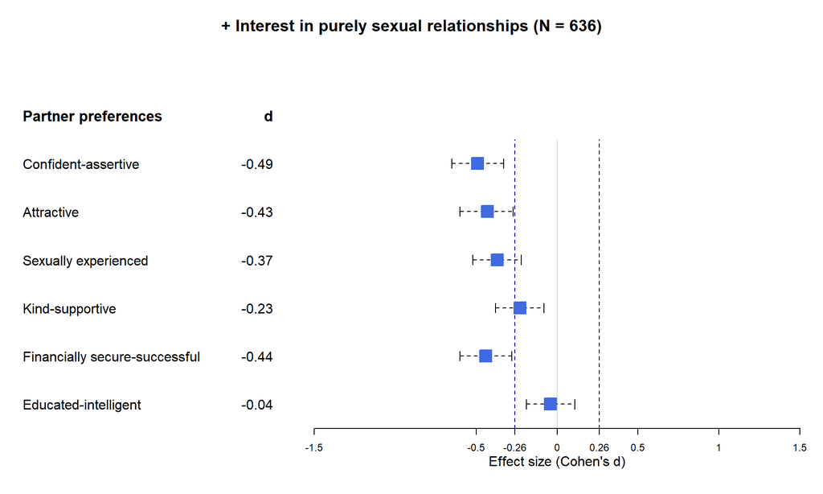

```r
base_data_add2 <- tibble(mean  = c(-0.49, -0.43, -0.37, -0.23, -0.44, -0.04),
                    lower = c(-0.65, -0.60, -0.52, -0.38, -0.60, -0.19),
                    upper = c(-0.33, -0.27, -0.22, -0.08, -0.28, 0.11),
                    Partner_preferences = c("Confident-assertive", "Attractive",
                                            "Sexually experienced", "Kind-supportive",
                                            "Financially secure-successful", "Educated-intelligent"),
                    d = c("-0.49", "-0.43", "-0.37", "-0.23", "-0.44", "-0.04"))

header_add2 <- tibble(Partner_preferences = c("", "Partner preferences"),
                d = c("", "d"),
                 summary = TRUE)

partner_preferences_add2 <- bind_rows(header_add2,
                                base_data_add2)



partner_preferences_add2 %>%
  forestplot(labeltext = c(Partner_preferences, d),
             graph.pos = 3,
              clip = c(-1,2),
             lty.ci = 2,
             boxsize = .25,
              is.summary = summary,
              grid = structure(c(-.26, .26),
                              gp = gpar(lty = 2, col = "darkblue")),
             xticks = c(-1.5, -.26, -0.5,0, .26, .5, 1, 1.5),
             xlab = "Effect size (Cohen's d)",
             txt_gp = fpTxtGp(ticks=gpar(cex=.75), xlab=gpar(cex=1)),
             col = fpColors(box = "royalblue",
                            line = "black",
                            summary = "royalblue"),
             title = "+ Interest in purely sexual relationships (N = 636)",
             graphwidth = unit(150, "mm"))
```

## 3. PSM with parenting interest

```r
# MatchIt does not allow missing values
data_main_nomiss_add3 <- data_main %>% select(id, language, age, sex, country, relationship_status,
                                              relationship_length, sexual_orientation,
                                              pref_imp_ks, pref_imp_att, pref_imp_fs, pref_imp_ca,
                                              pref_imp_ei, pref_imp_sexually_experienced,
                                              interest_nonsexrel, interest_monrel, interest_single,
                                              interest_parent) %>%
                                  na.omit()

table(is.na(data_main_nomiss_add3)) # no more NAs in data set
```

```
##
##  FALSE
## 677772
```

Check if correct variable type

```r
typeof(data_main_nomiss_add3$sexual_orientation) # is variable of type character, but for PSM it needs to be a factor
```

```
## [1] "character"
```

```r
data_main_nomiss_add3$sexual_orientation = as.factor(data_main_nomiss_add3$sexual_orientation) # convert to factor
levels(data_main_nomiss_add3$sexual_orientation) # check levels of factor
```

```
## [1] "Asexual"               "Straight/Heterosexual"
```

```r
data_main_nomiss_add3$sexual_orientation = factor(data_main_nomiss_add3$sexual_orientation,
                                             levels=rev(levels(data_main_nomiss_add3$sexual_orientation))) # reverse order of factor levels
levels(data_main_nomiss_add3$sexual_orientation) # check factor level order
```

```
## [1] "Straight/Heterosexual" "Asexual"
```

### Matching with NNM

```r
nnm_add3 <- matchit(sexual_orientation ~ language + age + country + relationship_status +
                      relationship_length + interest_nonsexrel + interest_monrel +
                      interest_single + interest_parent,
                    method = "nearest", data = data_main_nomiss_add3)

nnm_add3_data <- match.data(nnm_add3)

nrow(nnm_add3_data) # 634 observations
```

```
## [1] 634
```

```r
table(nnm_add3_data$subclass) # data includes only pairs of two observations
```

```
##
##   1   2   3   4   5   6   7   8   9  10  11  12  13  14  15  16  17  18  19  20
##   2   2   2   2   2   2   2   2   2   2   2   2   2   2   2   2   2   2   2   2
##  21  22  23  24  25  26  27  28  29  30  31  32  33  34  35  36  37  38  39  40
##   2   2   2   2   2   2   2   2   2   2   2   2   2   2   2   2   2   2   2   2
##  41  42  43  44  45  46  47  48  49  50  51  52  53  54  55  56  57  58  59  60
##   2   2   2   2   2   2   2   2   2   2   2   2   2   2   2   2   2   2   2   2
##  61  62  63  64  65  66  67  68  69  70  71  72  73  74  75  76  77  78  79  80
##   2   2   2   2   2   2   2   2   2   2   2   2   2   2   2   2   2   2   2   2
##  81  82  83  84  85  86  87  88  89  90  91  92  93  94  95  96  97  98  99 100
##   2   2   2   2   2   2   2   2   2   2   2   2   2   2   2   2   2   2   2   2
## 101 102 103 104 105 106 107 108 109 110 111 112 113 114 115 116 117 118 119 120
##   2   2   2   2   2   2   2   2   2   2   2   2   2   2   2   2   2   2   2   2
## 121 122 123 124 125 126 127 128 129 130 131 132 133 134 135 136 137 138 139 140
##   2   2   2   2   2   2   2   2   2   2   2   2   2   2   2   2   2   2   2   2
```

[output cut: 18 more lines]

```r
dim(nnm_add3_data) # 634 observations and 21 variables
```

```
## [1] 634  21
```

### Check balance

```r
summary_nnm_add3 = summary(nnm_add3, standardize = T)
print(summary_nnm_add3)
```

```
##
## Call:
## matchit(formula = sexual_orientation ~ language + age + country +
##     relationship_status + relationship_length + interest_nonsexrel +
##     interest_monrel + interest_single + interest_parent, data = data_main_nomiss_add3,
##     method = "nearest")
##
## Summary of Balance for All Data:
##                                         Means Treated Means Control
## distance                                       0.1261        0.0074
## languagechinese                                0.0000        0.0064
## languagedanish                                 0.0189        0.0304
## languageenglish                                0.5110        0.2300
## languagefrench                                 0.0631        0.1924
## languagegerman                                 0.1546        0.1469
## languageitalian                                0.0442        0.0659
## languagejapanese                               0.0284        0.0251
## languageportuguese                             0.0536        0.0725
## languagerussian                                0.0158        0.0166
## languagespanish                                0.1104        0.2138
## age                                           24.0694       25.2269
## countryAfghanistan                             0.0000        0.0001
## countryAlbania                                 0.0000        0.0001
## countryAlgeria                                 0.0032        0.0003
## countryAndorra                                 0.0000        0.0002
## countryAngola                                  0.0000        0.0001
## countryAntigua and Barbuda                     0.0000        0.0001
## countryArgentina                               0.0189        0.0152
## countryArmenia                                 0.0000        0.0001
## countryAruba                                   0.0000        0.0001
## countryAustralia                               0.0347        0.0108
## countryAustria                                 0.0095        0.0127
## countryAzerbaijan                              0.0000        0.0000
## countryBahamas, The                            0.0000        0.0001
## countryBahrain                                 0.0000        0.0001
## countryBarbados                                0.0000        0.0001
## countryBelarus                                 0.0000        0.0010
## countryBelgium                                 0.0000        0.0091
## countryBelize                                  0.0000        0.0001
## countryBenin                                   0.0000        0.0000
```

[output cut: 1437 more lines]

```
## relationship_statusLong-term                94.0
## relationship_statusNo relationship          97.2
## relationship_statusShort-term               89.4
## relationship_length                         84.5
## interest_nonsexrel                          95.8
## interest_monrel                             57.8
## interest_single                             89.4
## interest_parent                             82.3
##
## Sample Sizes:
##           Control Treated
## All         37337     317
## Matched       317     317
## Unmatched   37020       0
## Discarded       0       0
```

```r
tail(summary_nnm_add3$sum.matched) #look at balance properties for interest variables
```

```
##                               Means Treated Means Control Std. Mean Diff.
## relationship_statusShort-term    0.05047319    0.04100946      0.04322928
## relationship_length              1.17350158    1.30914826     -0.04260330
## interest_nonsexrel               4.37223975    4.43217666     -0.03427933
## interest_monrel                  4.34700315    4.41009464     -0.03785377
## interest_single                  3.30914826    3.34384858     -0.01851712
## interest_parent                  2.33753943    2.21766562      0.05449802
##                               Var. Ratio   eCDF Mean    eCDF Max
## relationship_statusShort-term         NA 0.009463722 0.009463722
## relationship_length            0.2870558 0.006107792 0.041009464
## interest_nonsexrel             1.0784601 0.008562416 0.022082019
## interest_monrel                0.7191271 0.054078414 0.094637224
## interest_single                0.9424069 0.008562416 0.034700315
## interest_parent                0.9472746 0.022532672 0.053627760
##                               Std. Pair Dist.
## relationship_statusShort-term       0.3602440
## relationship_length                 0.6945329
## interest_nonsexrel                  0.7234742
## interest_monrel                     1.1280424
## interest_single                     0.9511067
## interest_parent                     0.9666227
```

```r
bal.tab(nnm_add3, m.threshold = 0.1, un = T, binary = "std") #smd
```

```
## Call
##  matchit(formula = sexual_orientation ~ language + age + country +
##     relationship_status + relationship_length + interest_nonsexrel +
##     interest_monrel + interest_single + interest_parent, data = data_main_nomiss_add3,
##     method = "nearest")
##
## Balance Measures
##                                              Type Diff.Un Diff.Adj
## distance                                 Distance  0.8100   0.0266
## language_chinese                           Binary -0.0804   0.0000
## language_danish                            Binary -0.0840  -0.1389
## language_english                           Binary  0.5622  -0.0189
## language_french                            Binary -0.5320   0.0519
## language_german                            Binary  0.0212   0.0698
## language_italian                           Binary -0.1057   0.0307
## language_japanese                          Binary  0.0197   0.0000
## language_portuguese                        Binary -0.0838  -0.0700
## language_russian                           Binary -0.0063   0.0506
## language_spanish                           Binary -0.3300  -0.0201
## age                                       Contin. -0.1807  -0.0162
## country_Afghanistan                        Binary -0.0074   0.0000
## country_Albania                            Binary -0.0090   0.0000
## country_Algeria                            Binary  0.0505   0.0563
## country_Andorra                            Binary -0.0147   0.0000
## country_Angola                             Binary -0.0074   0.0000
## country_Antigua and Barbuda                Binary -0.0104   0.0000
## country_Argentina                          Binary  0.0275   0.0231
## country_Armenia                            Binary -0.0104   0.0000
## country_Aruba                              Binary -0.0074   0.0000
## country_Australia                          Binary  0.1303   0.0172
## country_Austria                            Binary -0.0331   0.0326
## country_Azerbaijan                         Binary -0.0052   0.0000
## country_Bahamas, The                       Binary -0.0104   0.0000
## country_Bahrain                            Binary -0.0090   0.0000
## country_Barbados                           Binary -0.0104   0.0000
## country_Belarus                            Binary -0.0312   0.0000
## country_Belgium                            Binary -0.0961   0.0000
## country_Belize                             Binary -0.0090   0.0000
## country_Benin                              Binary -0.0052   0.0000
## country_Bhutan                             Binary -0.0052   0.0000
```

[output cut: 335 more lines]

```
##
## Balance tally for mean differences
##                    count
## Balanced, <0.1       181
## Not Balanced, >0.1     2
##
## Variable with the greatest mean difference
##         Variable Diff.Adj        M.Threshold
##  country_Denmark   -0.162 Not Balanced, >0.1
##
## Sample sizes
##           Control Treated
## All         37337     317
## Matched       317     317
## Unmatched   37020       0
```

```r
bal.tab(nnm_add3, v.threshold = 2, un = T) #vr (can only be calculated for continuous variables)
```

```
## Call
##  matchit(formula = sexual_orientation ~ language + age + country +
##     relationship_status + relationship_length + interest_nonsexrel +
##     interest_monrel + interest_single + interest_parent, data = data_main_nomiss_add3,
##     method = "nearest")
##
## Balance Measures
##                                              Type Diff.Un V.Ratio.Un Diff.Adj
## distance                                 Distance  0.8100    33.0485   0.0266
## language_chinese                           Binary -0.0804          .   0.0000
## language_danish                            Binary -0.0840          .  -0.1389
## language_english                           Binary  0.5622          .  -0.0189
## language_french                            Binary -0.5320          .   0.0519
## language_german                            Binary  0.0212          .   0.0698
## language_italian                           Binary -0.1057          .   0.0307
## language_japanese                          Binary  0.0197          .   0.0000
## language_portuguese                        Binary -0.0838          .  -0.0700
## language_russian                           Binary -0.0063          .   0.0506
## language_spanish                           Binary -0.3300          .  -0.0201
## age                                       Contin. -0.1807     0.7859  -0.0162
## country_Afghanistan                        Binary -0.0074          .   0.0000
## country_Albania                            Binary -0.0090          .   0.0000
## country_Algeria                            Binary  0.0505          .   0.0563
## country_Andorra                            Binary -0.0147          .   0.0000
## country_Angola                             Binary -0.0074          .   0.0000
## country_Antigua and Barbuda                Binary -0.0104          .   0.0000
## country_Argentina                          Binary  0.0275          .   0.0231
## country_Armenia                            Binary -0.0104          .   0.0000
## country_Aruba                              Binary -0.0074          .   0.0000
## country_Australia                          Binary  0.1303          .   0.0172
## country_Austria                            Binary -0.0331          .   0.0326
## country_Azerbaijan                         Binary -0.0052          .   0.0000
## country_Bahamas, The                       Binary -0.0104          .   0.0000
## country_Bahrain                            Binary -0.0090          .   0.0000
## country_Barbados                           Binary -0.0104          .   0.0000
## country_Belarus                            Binary -0.0312          .   0.0000
## country_Belgium                            Binary -0.0961          .   0.0000
## country_Belize                             Binary -0.0090          .   0.0000
## country_Benin                              Binary -0.0052          .   0.0000
## country_Bhutan                             Binary -0.0052          .   0.0000
```

[output cut: 335 more lines]

```
##
## Balance tally for variance ratios
##                  count
## Balanced, <2         6
## Not Balanced, >2     1
##
## Variable with the greatest variance ratio
##             Variable V.Ratio.Adj      V.Threshold
##  relationship_length      0.2871 Not Balanced, >2
##
## Sample sizes
##           Control Treated
## All         37337     317
## Matched       317     317
## Unmatched   37020       0
```

No asexual unmatched. Based on smds 2 covariates not balanced (country_Denmark and langugage_danish). Based on vr, relationship_length is not balanced (vr = .29)

### Visualize

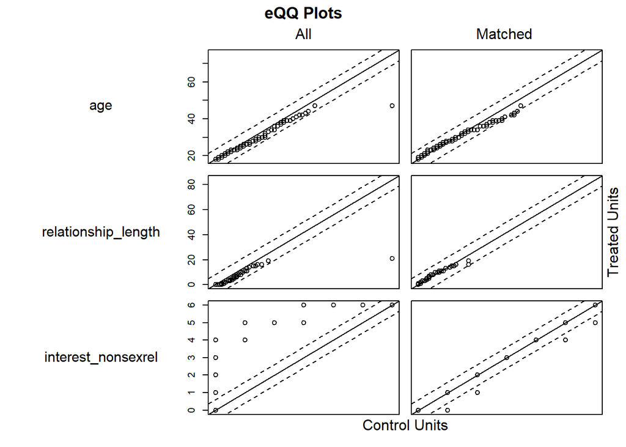

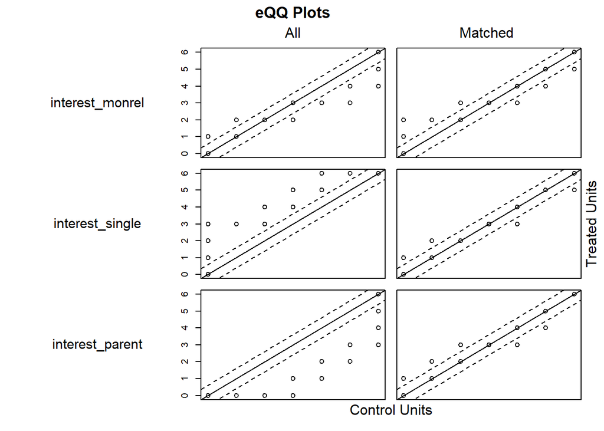

```r
# Q-Q plot
plot(nnm_add3, type = "qq", interactive = FALSE, which.xs = c("age", "relationship_length", "interest_nonsexrel", "interest_monrel", "interest_single", "interest_parent"))
```

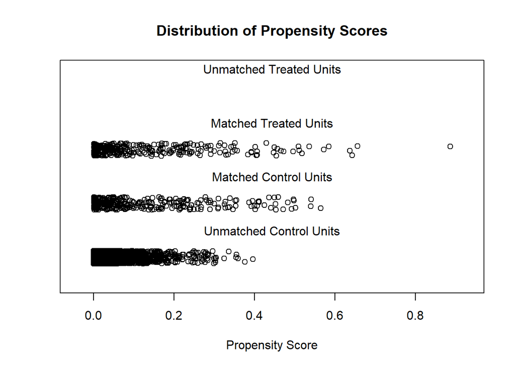

```r
# looks better after matching

# Jitter plot
plot(nnm_add3, type = "jitter", interactive = FALSE)
```

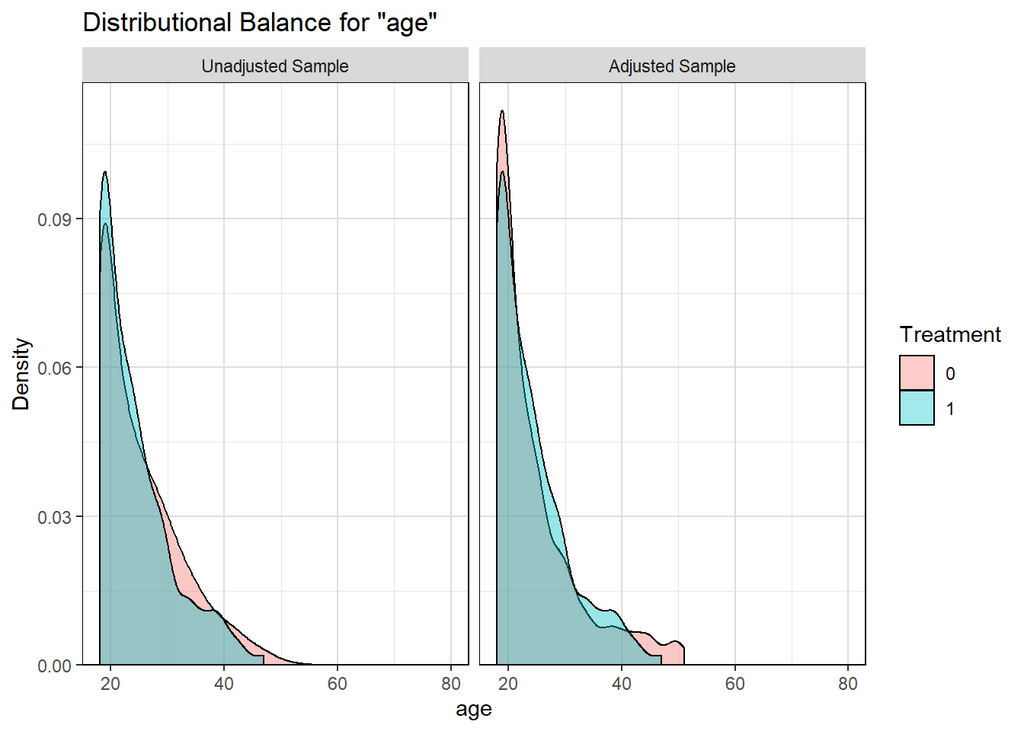

```r
# distributional density/histogram
bal.plot(nnm_add3, var.name = "age", which = "both", grid = T)
```

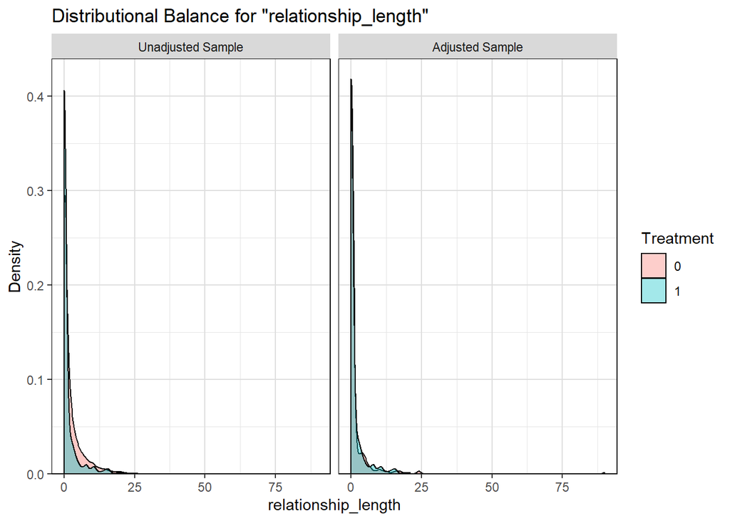

```r
bal.plot(nnm_add3, var.name = "relationship_length", which = "both", grid = T)
```

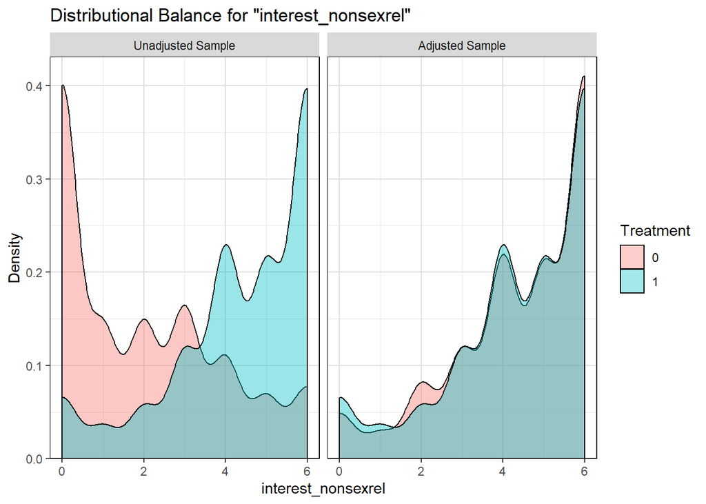

```r
bal.plot(nnm_add3, var.name = "interest_nonsexrel", which = "both", grid = T)
```

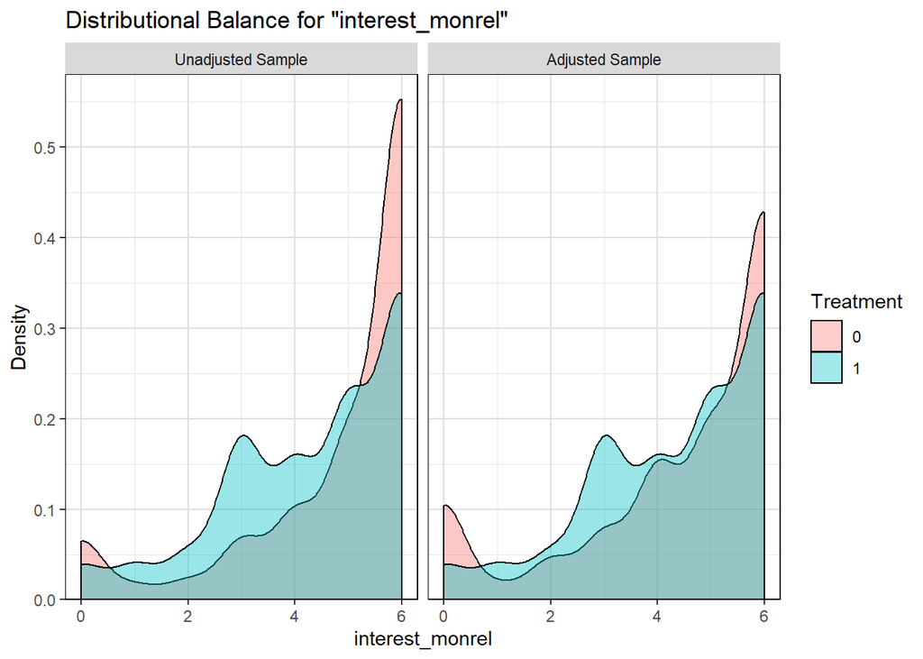

```r
bal.plot(nnm_add3, var.name = "interest_monrel", which = "both", grid = T)
```

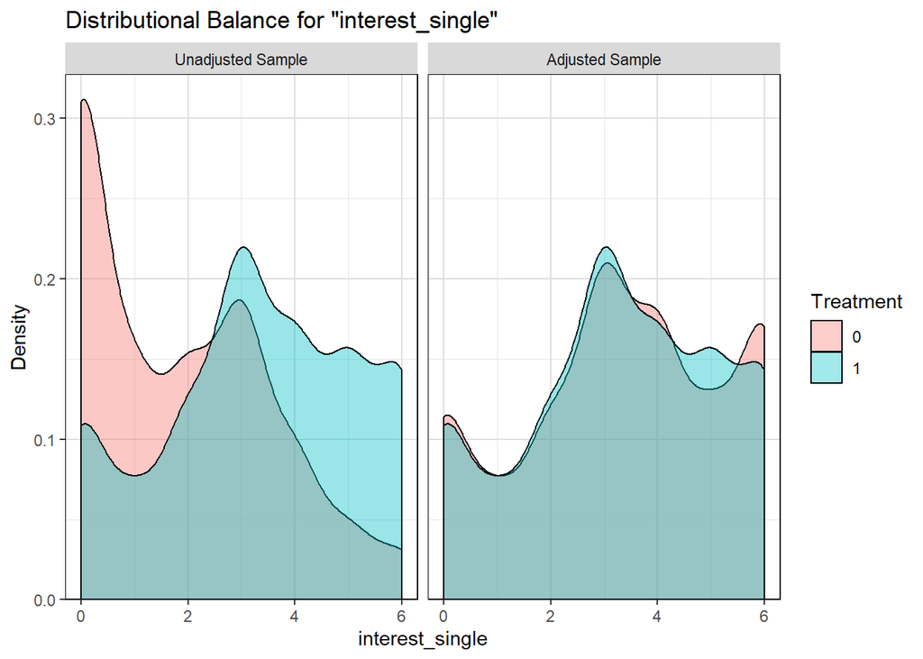

```r
bal.plot(nnm_add3, var.name = "interest_single", which = "both", grid = T)
```

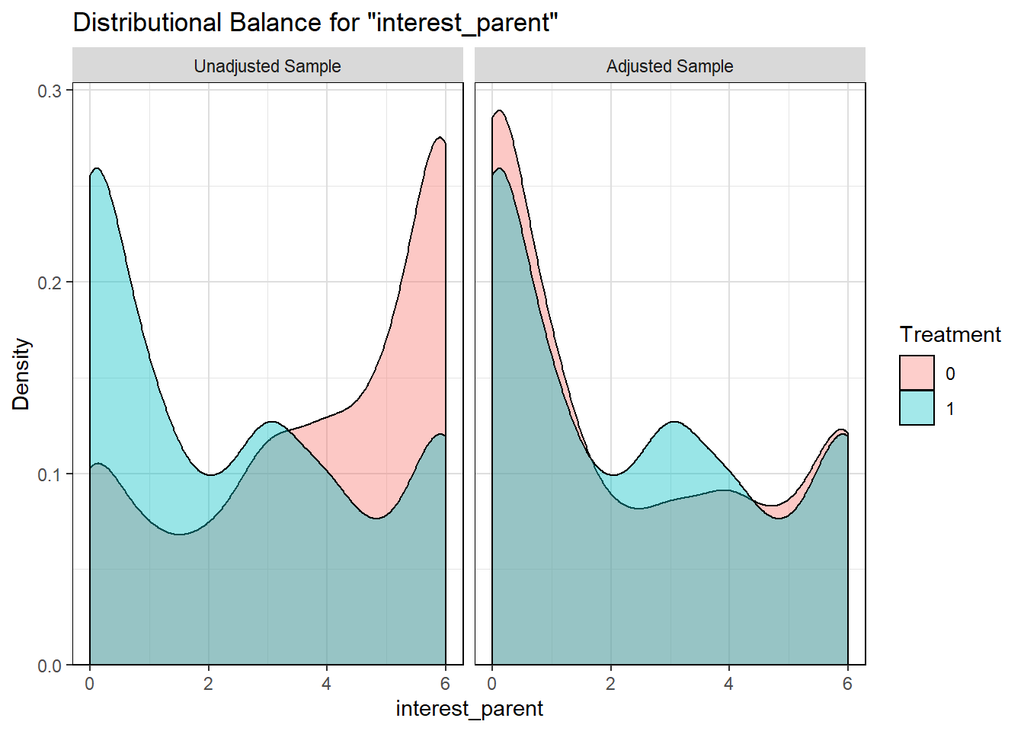

```r
bal.plot(nnm_add3, var.name = "interest_parent", which = "both", grid = T)
```

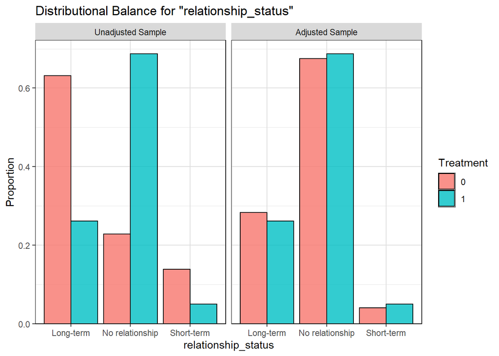

```r
bal.plot(nnm_add3, var.name = "relationship_status", which = "both", grid = T)
```

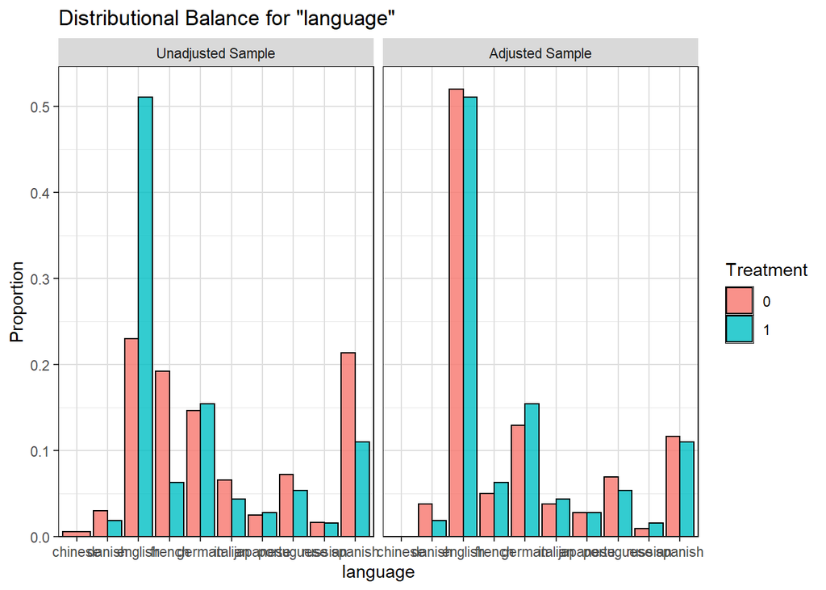

```r
bal.plot(nnm_add3, var.name = "language", which = "both", grid = T)
```

[figure not shown]

```r
bal.plot(nnm_add3, var.name = "country", which = "both", grid = T) # not readable
```

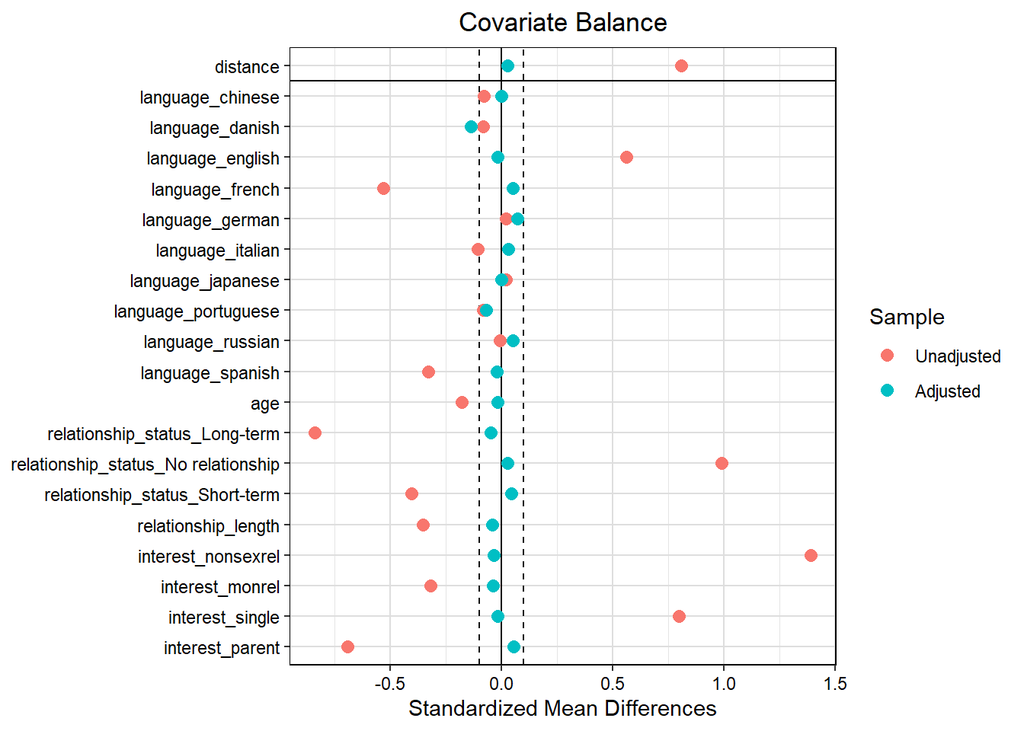

```r
# remove country variable for love plot
nnm_add3_without_country = nnm_add3
nnm_add3_without_country$X[c("country")] <- NULL

love.plot(bal.tab(nnm_add3_without_country, m.threshold = 0.1),
          stat = "mean.diffs",
          grid = T,
          stars = "raw",
          abs = F,
          binary = "std")
```

[figure not shown]

```r
## love plot using alternate variable names
# Using alternate variable names
v <- data.frame(old = c("distance", "language_chinese", "language_japanese", "language_german","language_english",
                        "language_italian", "language_danish", "language_spanish", "language_russian",
                        "language_portuguese", "language_french", "age", "relationship_status_Long-term",
                        "relationship_status_No relationship", "relationship_status_Short-term",
                        "relationship_length", "interest_nonsexrel", "interest_monrel", "interest_single",
                        "interest_parent"),
                new = c("Propensity scores", "Chinese", "Japanese", "German", "English", "Italian", "Danish",
                        "Spanish", "Russian", "Portuguese", "French", "Long-term relationship",
                        "No relationship", "Dating/Sexual Relationship","Age",  "Relationship length",
                        "Interest non-sexual, romantic relationships", "Interest monogamous relationships",
                        "Interest single", "Interest becoming a parent"))

love.plot(bal.tab(nnm_add3_without_country, m.threshold = 0.1, binary = "std"),
          stat = "mean.diffs",
          grid = T,
          stars = "raw",
          abs = F,
          sample.names = c("Before Matching", "After Matching"),
          var.names = v)
```

### Recalculate t-test for differences in partner preferences based on this psm sample controlling for having no interest in any long-term relationship

Sort data by subclass number within sexual_orientation

```r
data_add3 = nnm_add3_data %>%
        group_by(sexual_orientation) %>%
        arrange(subclass, .by_group = TRUE)

levels(data_add3$sexual_orientation) # check factor level
```

```
## [1] "Straight/Heterosexual" "Asexual"
```

```r
# for analyses, I reverse the factor levels so that 0 = Asexuals and 1 = Straight/Heterosexual
data_add3$sexual_orientation =  factor(data_add3$sexual_orientation,
                                             levels=rev(levels(data_add3$sexual_orientation))) # reverse order of factor levels
levels(data_add3$sexual_orientation) # check factor level order
```

```
## [1] "Asexual"               "Straight/Heterosexual"
```

#### Quick overview

```r
# mean
data_add3 %>% group_by(sexual_orientation) %>%
  summarise_at(c("pref_imp_ca",
                 "pref_imp_att",
                 "pref_imp_sexually_experienced",
                 "pref_imp_ks",
                 "pref_imp_fs",
                 "pref_imp_ei"), mean, na.rm = T)
```

```
## # A tibble: 2 x 7
##   sexual_orientation    pref_imp_ca pref_imp_att pref_imp_sexually_~ pref_imp_ks
##   <fct>                       <dbl>        <dbl>               <dbl>       <dbl>
## 1 Asexual                      3.91         3.18                1.31        5.47
## 2 Straight/Heterosexual        4.29         3.79                2.46        5.51
## # ... with 2 more variables: pref_imp_fs <dbl>, pref_imp_ei <dbl>
```

```r
# sd
data_add3 %>% group_by(sexual_orientation) %>%
  summarise_at(c("pref_imp_ca",
                 "pref_imp_att",
                 "pref_imp_sexually_experienced",
                 "pref_imp_ks",
                 "pref_imp_fs",
                 "pref_imp_ei"), sd, na.rm = T)
```

```
## # A tibble: 2 x 7
##   sexual_orientation    pref_imp_ca pref_imp_att pref_imp_sexually_~ pref_imp_ks
##   <fct>                       <dbl>        <dbl>               <dbl>       <dbl>
## 1 Asexual                     1.16          1.52                1.79       0.663
## 2 Straight/Heterosexual       0.987         1.30                2.08       0.614
## # ... with 2 more variables: pref_imp_fs <dbl>, pref_imp_ei <dbl>
```

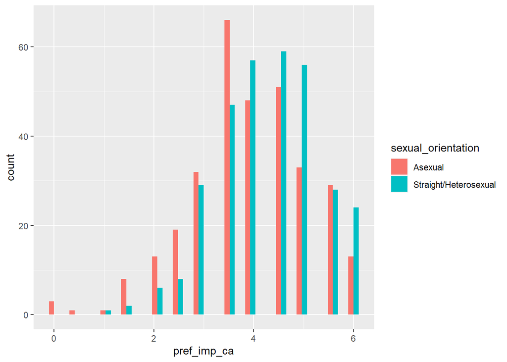

```r
# Visualize
# confident-assertive
ggplot(data_add3, aes(x = pref_imp_ca, fill = sexual_orientation)) +
  geom_histogram(position = "dodge")
```

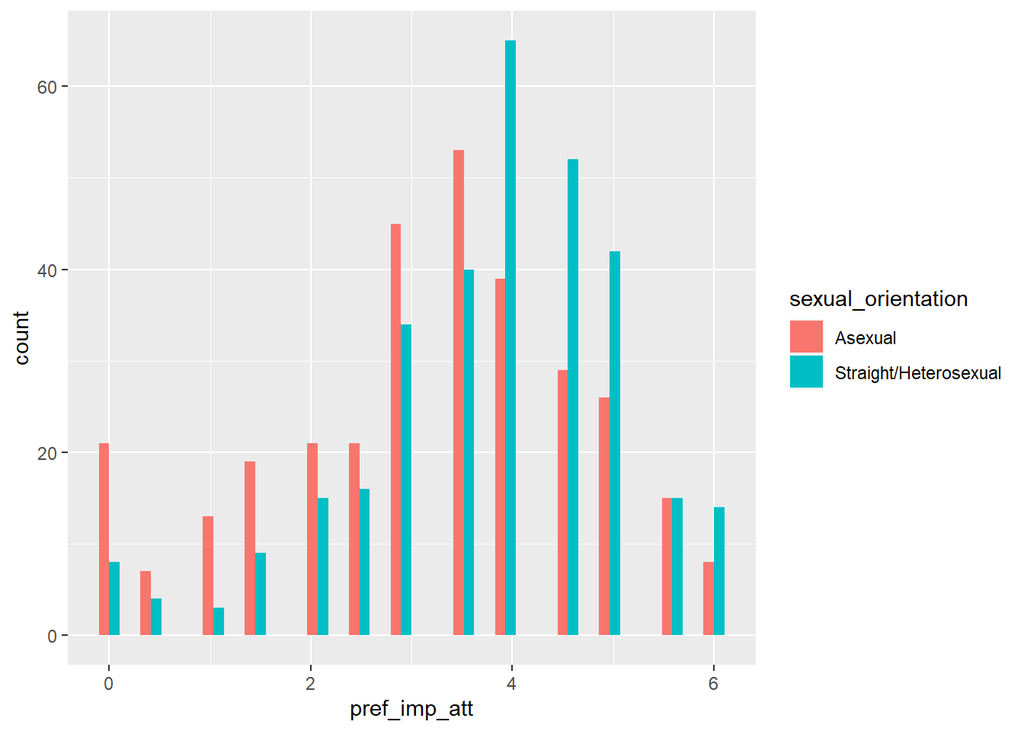

```r
# attractive
ggplot(data_add3, aes(x = pref_imp_att, fill = sexual_orientation)) +
  geom_histogram(position = "dodge")
```

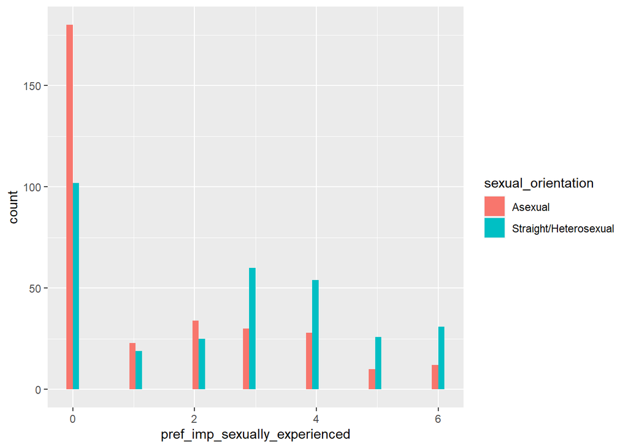

```r
# sexually experienced
ggplot(data_add3, aes(x = pref_imp_sexually_experienced, fill = sexual_orientation)) +
  geom_histogram(position = "dodge")
```

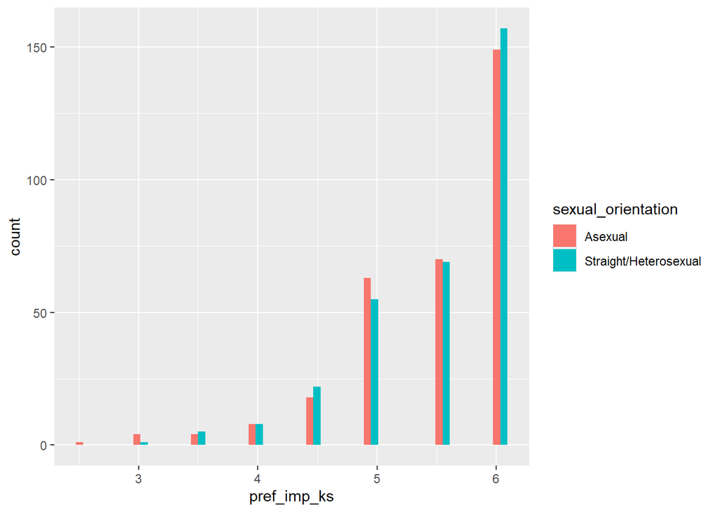

```r
# kind-supportive
ggplot(data_add3, aes(x = pref_imp_ks, fill = sexual_orientation)) +
  geom_histogram(position = "dodge")
```

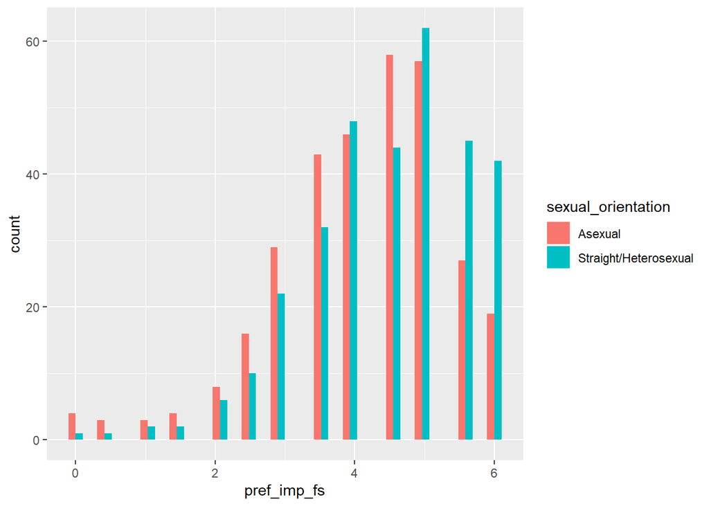

```r
# financially secure-successful
ggplot(data_add3, aes(x = pref_imp_fs, fill = sexual_orientation)) +
  geom_histogram(position = "dodge")
```

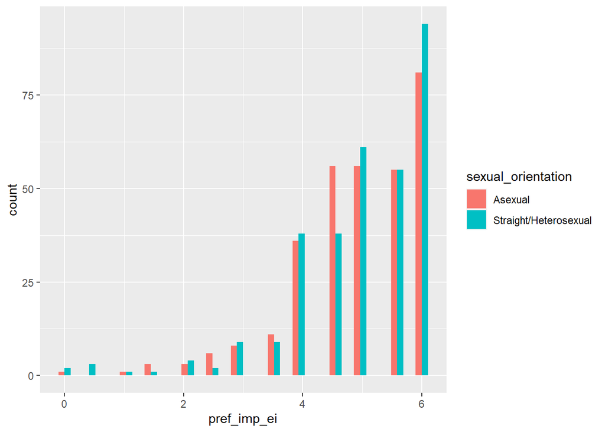

```r
# educated-intelligent
ggplot(data_add3, aes(x = pref_imp_ei, fill = sexual_orientation)) +
  geom_histogram(position = "dodge")
```

#### Confident-assertive

```r
t.test(pref_imp_ca ~ sexual_orientation,
       data = data_add3,
       alternative = "less",
       paired = TRUE)
```

```
##
##  Paired t-test
##
## data:  pref_imp_ca by sexual_orientation
## t = -4.5931, df = 316, p-value = 3.158e-06
## alternative hypothesis: true difference in means is less than 0
## 95 percent confidence interval:
##        -Inf -0.2446078
## sample estimates:
## mean of the differences
##              -0.3817035
```

```r
# effect size
effsize::cohen.d(pref_imp_ca ~ sexual_orientation, data = data_add3, paired = T)
```

```
##
## Cohen's d
##
## d estimate: -0.3549036 (small)
## 95 percent confidence interval:
##      lower      upper
## -0.5113438 -0.1984633
```

#### Attractive

```r
t.test(pref_imp_att ~ sexual_orientation,
       data = data_add3,
       alternative = "less",
       paired = TRUE)
```

```
##
##  Paired t-test
##
## data:  pref_imp_att by sexual_orientation
## t = -5.5346, df = 316, p-value = 3.279e-08
## alternative hypothesis: true difference in means is less than 0
## 95 percent confidence interval:
##        -Inf -0.4295738
## sample estimates:
## mean of the differences
##              -0.6119874
```

```r
# effect size
effsize::cohen.d(pref_imp_att ~ sexual_orientation, data = data_add3, paired = T)
```

```
##
## Cohen's d
##
## d estimate: -0.433008 (small)
## 95 percent confidence interval:
##      lower      upper
## -0.5936828 -0.2723333
```

#### Sexually experienced

```r
t.test(pref_imp_sexually_experienced ~ sexual_orientation,
       data = data_add3,
       alternative = "less",
       paired = TRUE)
```

```
##
##  Paired t-test
##
## data:  pref_imp_sexually_experienced by sexual_orientation
## t = -7.5942, df = 316, p-value = 1.764e-13
## alternative hypothesis: true difference in means is less than 0
## 95 percent confidence interval:
##        -Inf -0.9037643
## sample estimates:
## mean of the differences
##               -1.154574
```

```r
# effect size
effsize::cohen.d(pref_imp_sexually_experienced ~ sexual_orientation, data = data_add3, paired = T)
```

```
##
## Cohen's d
##
## d estimate: -0.5948072 (medium)
## 95 percent confidence interval:
##      lower      upper
## -0.7616650 -0.4279493
```

#### Exploratory analyses

##### Kind-supportive

```r
t.test(pref_imp_ks ~ sexual_orientation,
       data = data_add3,
       alternative = "two.sided",
       paired = TRUE)
```

```
##
##  Paired t-test
##
## data:  pref_imp_ks by sexual_orientation
## t = -0.76992, df = 316, p-value = 0.4419
## alternative hypothesis: true difference in means is not equal to 0
## 95 percent confidence interval:
##  -0.14019926  0.06133491
## sample estimates:
## mean of the differences
##             -0.03943218
```

```r
# effect size
effsize::cohen.d(pref_imp_ks ~ sexual_orientation, data = data_add3, paired = T)
```

```
##
## Cohen's d
##
## d estimate: -0.06171975 (negligible)
## 95 percent confidence interval:
##       lower       upper
## -0.21928892  0.09584942
```

##### Financially secure-successful

```r
t.test(pref_imp_fs ~ sexual_orientation,
       data = data_add3,
       alternative = "two.sided",
       paired = TRUE)
```

```
##
##  Paired t-test
##
## data:  pref_imp_fs by sexual_orientation
## t = -4.1587, df = 316, p-value = 4.129e-05
## alternative hypothesis: true difference in means is not equal to 0
## 95 percent confidence interval:
##  -0.5739086 -0.2052712
## sample estimates:
## mean of the differences
##              -0.3895899
```

```r
# effect size
effsize::cohen.d(pref_imp_fs ~ sexual_orientation, data = data_add3, paired = T)
```

```
##
## Cohen's d
##
## d estimate: -0.3319029 (small)
## 95 percent confidence interval:
##      lower      upper
## -0.4928864 -0.1709194
```

##### Educated-intelligent

```r
t.test(pref_imp_ei ~ sexual_orientation,
       data = data_add3,
       alternative = "two.sided",
       paired = TRUE)
```

```
##
##  Paired t-test
##
## data:  pref_imp_ei by sexual_orientation
## t = -0.63626, df = 316, p-value = 0.5251
## alternative hypothesis: true difference in means is not equal to 0
## 95 percent confidence interval:
##  -0.2130059  0.1089049
## sample estimates:
## mean of the differences
##             -0.05205047
```

```r
# effect size
effsize::cohen.d(pref_imp_ei ~ sexual_orientation, data = nnm_add3_data, paired = T)
```

[output not shown]

### Create forest plot

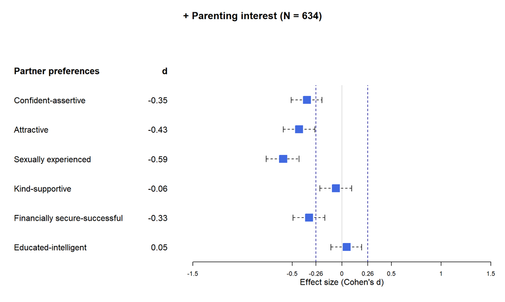

```r
base_data_add3 <- tibble(mean  = c(-0.35, -0.43, -0.59, -0.06, -0.33, 0.05),
                    lower = c(-0.51, -0.59, -0.76, -0.22, -0.49, -0.11),
                    upper = c(-0.20, -0.27, -0.43, 0.10, -0.17, 0.20),
                    Partner_preferences = c("Confident-assertive", "Attractive",
                                            "Sexually experienced", "Kind-supportive",
                                            "Financially secure-successful", "Educated-intelligent"),
                    d = c("-0.35", "-0.43", "-0.59", "-0.06", "-0.33", "0.05"))

header_add3 <- tibble(Partner_preferences = c("", "Partner preferences"),
                d = c("", "d"),
                 summary = TRUE)

partner_preferences_add3 <- bind_rows(header_add3,
                                base_data_add3)



partner_preferences_add3 %>%
  forestplot(labeltext = c(Partner_preferences, d),
             graph.pos = 3,
              clip = c(-1,2),
             lty.ci = 2,
             boxsize = .25,
              is.summary = summary,
              grid = structure(c(-.26, .26),
                              gp = gpar(lty = 2, col = "darkblue")),
             xticks = c(-1.5, -.26, -0.5,0, .26, .5, 1, 1.5),
             xlab = "Effect size (Cohen's d)",
             txt_gp = fpTxtGp(ticks=gpar(cex=.75), xlab=gpar(cex=1)),
             col = fpColors(box = "royalblue",
                            line = "black",
                            summary = "royalblue"),
             title = "+ Parenting interest (N = 634)",
             graphwidth = unit(150, "mm"))
```